# Visualizing The Intervention - Mountain Division

```r
# Join divisional data to nmtc_awards_pre2010, set count to 0 if no data
svi_divisional_nmtc_eligible <-
  left_join(svi_divisional_nmtc_eligible, nmtc_awards_pre2010, join_by("GEOID_2010_trt" == "GEOID10")) %>%
  mutate(pre10_nmtc_project_cnt = if_else(is.na(pre10_nmtc_project_cnt), 0, pre10_nmtc_project_cnt)) %>%
    mutate(pre10_nmtc_dollars = if_else(is.na(pre10_nmtc_dollars), 0, pre10_nmtc_dollars)) %>%
    mutate(pre10_nmtc_dollars_formatted = if_else(is.na(pre10_nmtc_dollars_formatted), "$0", pre10_nmtc_dollars_formatted))

# View table
svi_divisional_nmtc_eligible %>% head() %>% kbl() %>% kable_styling() %>% scroll_box(width = "100%")
```

| GEOID_2010_trt | FIPS_st | FIPS_county | FIPS_tract | state | state_name | county | region_number | region | division_number | division | E_TOTPOP_10 | E_HU_10 | E_HH_10 | E_POV150_10 | ET_POVSTATUS_10 | EP_POV150_10 | EPL_POV150_10 | F_POV150_10 | E_UNEMP_10 | ET_EMPSTATUS_10 | EP_UNEMP_10 | EPL_UNEMP_10 | F_UNEMP_10 | E_HBURD_OWN_10 | ET_HOUSINGCOST_OWN_10 | EP_HBURD_OWN_10 | EPL_HBURD_OWN_10 | F_HBURD_OWN_10 | E_HBURD_RENT_10 | … |
| --- | --- | --- | --- | --- | --- | --- | --- | --- | --- | --- | --- | --- | --- | --- | --- | --- | --- | --- | --- | --- | --- | --- | --- | --- | --- | --- | --- | --- | --- | --- |
| 04001942600 | 04 | 001 | 942600 | AZ | Arizona | Apache County | 4 | West Region | 8 | Mountain Division | 1561 | 762 | 384 | 1150 | 1561 | 73.67072 | 0.9944 | 1 | 26 | 300 | 8.666667 | 0.6866 | 0 | 65 | 366 | 17.759563 | 0.10180 | 0 | 5 | … |
| 04001942700 | 04 | 001 | 942700 | AZ | Arizona | Apache County | 4 | West Region | 8 | Mountain Division | 4886 | 2757 | 1291 | 2616 | 4871 | 53.70560 | 0.9480 | 1 | 163 | 1398 | 11.659514 | 0.8577 | 1 | 102 | 1113 | 9.164421 | 0.01757 | 0 | 54 | … |
| 04001944000 | 04 | 001 | 944000 | AZ | Arizona | Apache County | 4 | West Region | 8 | Mountain Division | 5958 | 2178 | 1275 | 3112 | 5958 | 52.23229 | 0.9399 | 1 | 107 | 1895 | 5.646438 | 0.4130 | 0 | 108 | 880 | 12.272727 | 0.03476 | 0 | 112 | … |
| 04001944100 | 04 | 001 | 944100 | AZ | Arizona | Apache County | 4 | West Region | 8 | Mountain Division | 4975 | 2485 | 1204 | 3251 | 4968 | 65.43881 | 0.9846 | 1 | 210 | 1254 | 16.746412 | 0.9576 | 1 | 122 | 905 | 13.480663 | 0.04383 | 0 | 91 | … |
| 04001944201 | 04 | 001 | 944201 | AZ | Arizona | Apache County | 4 | West Region | 8 | Mountain Division | 3751 | 1392 | 984 | 2202 | 3689 | 59.69097 | 0.9743 | 1 | 242 | 1082 | 22.365989 | 0.9848 | 1 | 99 | 409 | 24.205379 | 0.27880 | 0 | 92 | … |
| 04001944202 | 04 | 001 | 944202 | AZ | Arizona | Apache County | 4 | West Region | 8 | Mountain Division | 3330 | 1463 | 897 | 1814 | 3330 | 54.47447 | 0.9514 | 1 | 345 | 1024 | 33.691406 | 0.9983 | 1 | 58 | 745 | 7.785235 | 0.01352 | 0 | 38 | … |

```r
# Join national data to nmtc_awards_pre2010, set count to 0 if no data
svi_national_nmtc_eligible <-
  left_join(svi_national_nmtc_eligible, nmtc_awards_pre2010, join_by("GEOID_2010_trt" == "GEOID10")) %>%
  mutate(pre10_nmtc_project_cnt = if_else(is.na(pre10_nmtc_project_cnt), 0, pre10_nmtc_project_cnt)) %>%
    mutate(pre10_nmtc_dollars = if_else(is.na(pre10_nmtc_dollars), 0, pre10_nmtc_dollars))%>%
    mutate(pre10_nmtc_dollars_formatted = if_else(is.na(pre10_nmtc_dollars_formatted), "$0", pre10_nmtc_dollars_formatted))

# View table
svi_national_nmtc_eligible %>% head() %>% kbl() %>% kable_styling() %>% scroll_box(width = "100%")
```

| GEOID_2010_trt | FIPS_st | FIPS_county | FIPS_tract | state | state_name | county | region_number | region | division_number | division | E_TOTPOP_10 | E_HU_10 | E_HH_10 | E_POV150_10 | ET_POVSTATUS_10 | EP_POV150_10 | EPL_POV150_10 | F_POV150_10 | E_UNEMP_10 | ET_EMPSTATUS_10 | EP_UNEMP_10 | EPL_UNEMP_10 | F_UNEMP_10 | E_HBURD_OWN_10 | ET_HOUSINGCOST_OWN_10 | EP_HBURD_OWN_10 | EPL_HBURD_OWN_10 | F_HBURD_OWN_10 | E_HBURD_RENT_10 | … |
| --- | --- | --- | --- | --- | --- | --- | --- | --- | --- | --- | --- | --- | --- | --- | --- | --- | --- | --- | --- | --- | --- | --- | --- | --- | --- | --- | --- | --- | --- | --- |
| 01001020200 | 01 | 001 | 020200 | AL | Alabama | Autauga County | 3 | South Region | 6 | East South Central Division | 2020 | 816 | 730 | 495 | 1992 | 24.84940 | 0.5954 | 0 | 68 | 834 | 8.153477 | 0.57540 | 0 | 49 | 439 | 11.16173 | 0.02067 | 0 | 105 | … |
| 01001020700 | 01 | 001 | 020700 | AL | Alabama | Autauga County | 3 | South Region | 6 | East South Central Division | 2664 | 1254 | 1139 | 710 | 2664 | 26.65165 | 0.6328 | 0 | 29 | 1310 | 2.213741 | 0.05255 | 0 | 134 | 710 | 18.87324 | 0.13890 | 0 | 187 | … |
| 01001021100 | 01 | 001 | 021100 | AL | Alabama | Autauga County | 3 | South Region | 6 | East South Central Division | 3298 | 1502 | 1323 | 860 | 3298 | 26.07641 | 0.6211 | 0 | 297 | 1605 | 18.504673 | 0.94340 | 1 | 250 | 1016 | 24.60630 | 0.32070 | 0 | 74 | … |
| 01003010200 | 01 | 003 | 010200 | AL | Alabama | Baldwin County | 3 | South Region | 6 | East South Central Division | 2612 | 1220 | 1074 | 338 | 2605 | 12.97505 | 0.2907 | 0 | 44 | 1193 | 3.688181 | 0.14720 | 0 | 172 | 928 | 18.53448 | 0.13090 | 0 | 31 | … |
| 01003010500 | 01 | 003 | 010500 | AL | Alabama | Baldwin County | 3 | South Region | 6 | East South Central Division | 4230 | 1779 | 1425 | 498 | 3443 | 14.46413 | 0.3337 | 0 | 166 | 1625 | 10.215385 | 0.71790 | 0 | 151 | 1069 | 14.12535 | 0.04638 | 0 | 196 | … |
| 01003010600 | 01 | 003 | 010600 | AL | Alabama | Baldwin County | 3 | South Region | 6 | East South Central Division | 3724 | 1440 | 1147 | 1973 | 3724 | 52.98067 | 0.9342 | 1 | 142 | 1439 | 9.867964 | 0.69680 | 0 | 235 | 688 | 34.15698 | 0.62950 | 0 | 187 | … |

```r
# Find count of NMTC projects after 2010
# Remove all tracts that do not have SVI flag counts for 2010
# Remove all tracts that do not have SVI flag counts for 2020
# Remove all tracts that had an NMTC project before 2010
svi_divisional_nmtc <-
  left_join(svi_divisional_nmtc_eligible, nmtc_awards_post2010, join_by("GEOID_2010_trt" == "GEOID10")) %>%
  mutate(post10_nmtc_project_cnt = if_else(is.na(post10_nmtc_project_cnt), 0, post10_nmtc_project_cnt)) %>%
  mutate(post10_nmtc_dollars = if_else(is.na(post10_nmtc_dollars), 0, post10_nmtc_dollars))%>%
  mutate(post10_nmtc_dollars_formatted = if_else(is.na(post10_nmtc_dollars_formatted), "$0", post10_nmtc_dollars_formatted)) %>%
  mutate(nmtc_flag = if_else(post10_nmtc_project_cnt > 0, 1, 0)) %>%
  filter(!is.na(F_TOTAL_10)) %>%
  filter(!is.na(F_TOTAL_20)) %>%
  filter(pre10_nmtc_project_cnt < 1)

svi_divisional_nmtc %>% head() %>% kbl() %>% kable_styling() %>% scroll_box(width = "100%")
```

| GEOID_2010_trt | FIPS_st | FIPS_county | FIPS_tract | state | state_name | county | region_number | region | division_number | division | E_TOTPOP_10 | E_HU_10 | E_HH_10 | E_POV150_10 | ET_POVSTATUS_10 | EP_POV150_10 | EPL_POV150_10 | F_POV150_10 | E_UNEMP_10 | ET_EMPSTATUS_10 | EP_UNEMP_10 | EPL_UNEMP_10 | F_UNEMP_10 | E_HBURD_OWN_10 | ET_HOUSINGCOST_OWN_10 | EP_HBURD_OWN_10 | EPL_HBURD_OWN_10 | F_HBURD_OWN_10 | E_HBURD_RENT_10 | … |
| --- | --- | --- | --- | --- | --- | --- | --- | --- | --- | --- | --- | --- | --- | --- | --- | --- | --- | --- | --- | --- | --- | --- | --- | --- | --- | --- | --- | --- | --- | --- |
| 04001942600 | 04 | 001 | 942600 | AZ | Arizona | Apache County | 4 | West Region | 8 | Mountain Division | 1561 | 762 | 384 | 1150 | 1561 | 73.67072 | 0.9944 | 1 | 26 | 300 | 8.666667 | 0.6866 | 0 | 65 | 366 | 17.759563 | 0.10180 | 0 | 5 | … |
| 04001942700 | 04 | 001 | 942700 | AZ | Arizona | Apache County | 4 | West Region | 8 | Mountain Division | 4886 | 2757 | 1291 | 2616 | 4871 | 53.70560 | 0.9480 | 1 | 163 | 1398 | 11.659514 | 0.8577 | 1 | 102 | 1113 | 9.164421 | 0.01757 | 0 | 54 | … |
| 04001944000 | 04 | 001 | 944000 | AZ | Arizona | Apache County | 4 | West Region | 8 | Mountain Division | 5958 | 2178 | 1275 | 3112 | 5958 | 52.23229 | 0.9399 | 1 | 107 | 1895 | 5.646438 | 0.4130 | 0 | 108 | 880 | 12.272727 | 0.03476 | 0 | 112 | … |
| 04001944100 | 04 | 001 | 944100 | AZ | Arizona | Apache County | 4 | West Region | 8 | Mountain Division | 4975 | 2485 | 1204 | 3251 | 4968 | 65.43881 | 0.9846 | 1 | 210 | 1254 | 16.746412 | 0.9576 | 1 | 122 | 905 | 13.480663 | 0.04383 | 0 | 91 | … |
| 04001944202 | 04 | 001 | 944202 | AZ | Arizona | Apache County | 4 | West Region | 8 | Mountain Division | 3330 | 1463 | 897 | 1814 | 3330 | 54.47447 | 0.9514 | 1 | 345 | 1024 | 33.691406 | 0.9983 | 1 | 58 | 745 | 7.785235 | 0.01352 | 0 | 38 | … |
| 04001944300 | 04 | 001 | 944300 | AZ | Arizona | Apache County | 4 | West Region | 8 | Mountain Division | 6806 | 3308 | 1826 | 4099 | 6797 | 60.30602 | 0.9762 | 1 | 403 | 1777 | 22.678672 | 0.9858 | 1 | 154 | 1457 | 10.569664 | 0.02549 | 0 | 63 | … |

```r
# Find count of NMTC projects after 2010
# Remove all tracts that do not have SVI flag counts for 2010
# Remove all tracts that do not have SVI flag counts for 2020
# Remove all tracts that had an NMTC project before 2010
svi_national_nmtc <-
  left_join(svi_national_nmtc_eligible, nmtc_awards_post2010, join_by("GEOID_2010_trt" == "GEOID10")) %>%
  mutate(post10_nmtc_project_cnt = if_else(is.na(post10_nmtc_project_cnt), 0, post10_nmtc_project_cnt)) %>%
  mutate(post10_nmtc_dollars = if_else(is.na(post10_nmtc_dollars), 0, post10_nmtc_dollars))%>%
  mutate(post10_nmtc_dollars_formatted = if_else(is.na(post10_nmtc_dollars_formatted), "$0", post10_nmtc_dollars_formatted)) %>%
  mutate(nmtc_flag = if_else(post10_nmtc_project_cnt > 0, 1, 0)) %>%
  filter(!is.na(F_TOTAL_10)) %>%
  filter(!is.na(F_TOTAL_20)) %>%
  filter(pre10_nmtc_project_cnt < 1)

svi_national_nmtc %>% head() %>% kbl() %>% kable_styling() %>% scroll_box(width = "100%")
```

| GEOID_2010_trt | FIPS_st | FIPS_county | FIPS_tract | state | state_name | county | region_number | region | division_number | division | E_TOTPOP_10 | E_HU_10 | E_HH_10 | E_POV150_10 | ET_POVSTATUS_10 | EP_POV150_10 | EPL_POV150_10 | F_POV150_10 | E_UNEMP_10 | ET_EMPSTATUS_10 | EP_UNEMP_10 | EPL_UNEMP_10 | F_UNEMP_10 | E_HBURD_OWN_10 | ET_HOUSINGCOST_OWN_10 | EP_HBURD_OWN_10 | EPL_HBURD_OWN_10 | F_HBURD_OWN_10 | E_HBURD_RENT_10 | … |
| --- | --- | --- | --- | --- | --- | --- | --- | --- | --- | --- | --- | --- | --- | --- | --- | --- | --- | --- | --- | --- | --- | --- | --- | --- | --- | --- | --- | --- | --- | --- |
| 01001020200 | 01 | 001 | 020200 | AL | Alabama | Autauga County | 3 | South Region | 6 | East South Central Division | 2020 | 816 | 730 | 495 | 1992 | 24.84940 | 0.5954 | 0 | 68 | 834 | 8.153477 | 0.57540 | 0 | 49 | 439 | 11.16173 | 0.02067 | 0 | 105 | … |
| 01001020700 | 01 | 001 | 020700 | AL | Alabama | Autauga County | 3 | South Region | 6 | East South Central Division | 2664 | 1254 | 1139 | 710 | 2664 | 26.65165 | 0.6328 | 0 | 29 | 1310 | 2.213741 | 0.05255 | 0 | 134 | 710 | 18.87324 | 0.13890 | 0 | 187 | … |
| 01001021100 | 01 | 001 | 021100 | AL | Alabama | Autauga County | 3 | South Region | 6 | East South Central Division | 3298 | 1502 | 1323 | 860 | 3298 | 26.07641 | 0.6211 | 0 | 297 | 1605 | 18.504673 | 0.94340 | 1 | 250 | 1016 | 24.60630 | 0.32070 | 0 | 74 | … |
| 01003010200 | 01 | 003 | 010200 | AL | Alabama | Baldwin County | 3 | South Region | 6 | East South Central Division | 2612 | 1220 | 1074 | 338 | 2605 | 12.97505 | 0.2907 | 0 | 44 | 1193 | 3.688181 | 0.14720 | 0 | 172 | 928 | 18.53448 | 0.13090 | 0 | 31 | … |
| 01003010500 | 01 | 003 | 010500 | AL | Alabama | Baldwin County | 3 | South Region | 6 | East South Central Division | 4230 | 1779 | 1425 | 498 | 3443 | 14.46413 | 0.3337 | 0 | 166 | 1625 | 10.215385 | 0.71790 | 0 | 151 | 1069 | 14.12535 | 0.04638 | 0 | 196 | … |
| 01003010600 | 01 | 003 | 010600 | AL | Alabama | Baldwin County | 3 | South Region | 6 | East South Central Division | 3724 | 1440 | 1147 | 1973 | 3724 | 52.98067 | 0.9342 | 1 | 142 | 1439 | 9.867964 | 0.69680 | 0 | 235 | 688 | 34.15698 | 0.62950 | 0 | 187 | … |

```r
svi_national_nmtc_county_sum <- summarize_county_nmtc(svi_national_nmtc)

svi_national_nmtc_county_sum %>% head() %>% kbl() %>% kable_styling() %>% scroll_box(width = "100%")
```

| State | County | Division | post10_nmtc_project_cnt | tract_cnt | post10_nmtc_project_dollars | post10_nmtc_dollars_formatted |
| --- | --- | --- | --- | --- | --- | --- |
| AK | Aleutians East Borough | Pacific Division | 1 | 1 | 15762500 | $15,762,500 |
| AK | Aleutians West Census Area | Pacific Division | 0 | 1 | 0 | $0 |
| AK | Anchorage Municipality | Pacific Division | 1 | 13 | 9800000 | $9,800,000 |
| AK | Bethel Census Area | Pacific Division | 0 | 1 | 0 | $0 |
| AK | Fairbanks North Star Borough | Pacific Division | 0 | 4 | 0 | $0 |
| AK | Hoonah-Angoon Census Area | Pacific Division | 0 | 1 | 0 | $0 |

```r
svi_divisional_nmtc_county_sum <- summarize_county_nmtc(svi_divisional_nmtc)
svi_divisional_nmtc_county_sum %>% head() %>% kbl() %>% kable_styling() %>% scroll_box(width = "100%")
```

| State | County | Division | post10_nmtc_project_cnt | tract_cnt | post10_nmtc_project_dollars | post10_nmtc_dollars_formatted |
| --- | --- | --- | --- | --- | --- | --- |
| AZ | Apache County | Mountain Division | 1 | 14 | 12544000 | $12,544,000 |
| AZ | Cochise County | Mountain Division | 0 | 16 | 0 | $0 |
| AZ | Coconino County | Mountain Division | 0 | 13 | 0 | $0 |
| AZ | Gila County | Mountain Division | 1 | 11 | 5390000 | $5,390,000 |
| AZ | Graham County | Mountain Division | 0 | 4 | 0 | $0 |
| AZ | Greenlee County | Mountain Division | 0 | 1 | 0 | $0 |

```r
# Create data frame of NMTC eligible tracts 2010 nationally
svi_national_nmtc10 <- svi_national_nmtc %>% select(GEOID_2010_trt, FIPS_st, FIPS_county,
    state, state_name, county, region_number, region, division_number,
    division, F_TOTAL_10, E_TOTPOP_10) %>% rename("F_TOTAL" = "F_TOTAL_10")

# Count national-level SVI flags for 2010, create unified fips column
svi_2010_national_county_flags_nmtc <- flag_summarize(svi_national_nmtc10, "E_TOTPOP_10") %>% unite("fips_county_st", FIPS_st:FIPS_county, remove = FALSE, sep="")

# Add suffix to flag columns 2010
colnames(svi_2010_national_county_flags_nmtc)[11:15] <- paste0(colnames(svi_2010_national_county_flags_nmtc)[11:15], 10)

# Create data frame of NMTC eligible tracts 2020 nationally
svi_national_nmtc20 <- svi_national_nmtc %>% select(GEOID_2010_trt, FIPS_st, FIPS_county,
    state, state_name, county, region_number, region, division_number,
    division, F_TOTAL_20, E_TOTPOP_20) %>% rename("F_TOTAL" = "F_TOTAL_20")

# Count national-level SVI flags for 2020, create unified fips column
svi_2020_national_county_flags_nmtc <- flag_summarize(svi_national_nmtc20, "E_TOTPOP_20") %>% unite("fips_county_st", FIPS_st:FIPS_county, remove = FALSE, sep="")

# Identify needed columns for 2020, add suffix
colnames(svi_2020_national_county_flags_nmtc)[11:15] <- paste0(colnames(svi_2020_national_county_flags_nmtc)[11:15], "20")

# Filter to needed columns for 2020 to avoid duplicate column column names
svi_2020_national_county_flags_join_nmtc <- svi_2020_national_county_flags_nmtc %>% ungroup() %>% select("fips_county_st", all_of(colnames(svi_2020_national_county_flags_nmtc)[11:15]))

# Join 2010 and 2020 data
svi_national_county_flags_nmtc <- left_join(svi_2010_national_county_flags_nmtc, svi_2020_national_county_flags_join_nmtc, join_by("fips_county_st" == "fips_county_st"))

svi_national_county_flags_nmtc %>% head() %>% kbl() %>% kable_styling() %>% scroll_box(width = "100%")
```

| fips_county_st | FIPS_st | FIPS_county | state | state_name | county | region_number | region | division_number | division | flag_count10 | pop10 | flag_by_pop10 | flag_count_quantile10 | flag_pop_quantile10 | flag_count20 | pop20 | flag_by_pop20 | flag_count_quantile20 | flag_pop_quantile20 |
| --- | --- | --- | --- | --- | --- | --- | --- | --- | --- | --- | --- | --- | --- | --- | --- | --- | --- | --- | --- |
| 01001 | 01 | 001 | AL | Alabama | Autauga County | 3 | South Region | 6 | East South Central Division | 14 | 7982 | 0.0017539 | 0.6 | 0.8 | 18 | 8818 | 0.0020413 | 0.6 | 1.0 |
| 01003 | 01 | 003 | AL | Alabama | Baldwin County | 3 | South Region | 6 | East South Central Division | 34 | 38458 | 0.0008841 | 0.8 | 0.4 | 34 | 46255 | 0.0007351 | 0.8 | 0.2 |
| 01005 | 01 | 005 | AL | Alabama | Barbour County | 3 | South Region | 6 | East South Central Division | 43 | 21287 | 0.0020200 | 0.8 | 1.0 | 44 | 18811 | 0.0023391 | 0.8 | 1.0 |
| 01007 | 01 | 007 | AL | Alabama | Bibb County | 3 | South Region | 6 | East South Central Division | 11 | 17570 | 0.0006261 | 0.4 | 0.2 | 16 | 17663 | 0.0009058 | 0.6 | 0.4 |
| 01009 | 01 | 009 | AL | Alabama | Blount County | 3 | South Region | 6 | East South Central Division | 12 | 16995 | 0.0007061 | 0.4 | 0.2 | 8 | 16546 | 0.0004835 | 0.4 | 0.2 |
| 01011 | 01 | 011 | AL | Alabama | Bullock County | 3 | South Region | 6 | East South Central Division | 21 | 10923 | 0.0019225 | 0.6 | 1.0 | 18 | 10173 | 0.0017694 | 0.6 | 0.8 |

```r
svi_national_county_nmtc <- left_join(svi_national_nmtc_county_sum,
                                      svi_national_county_flags_nmtc,
                                    join_by("State" == "state", "County" == "county",
                                            "Division" == "division"))

svi_national_county_nmtc$post10_nmtc_project_cnt[is.na(svi_national_county_nmtc$post10_nmtc_project_cnt)] <- 0

svi_national_county_nmtc$county_name <- paste0(svi_national_county_nmtc$County, ", ", svi_national_county_nmtc$State)

svi_national_county_nmtc %>% head() %>% kbl() %>% kable_styling() %>% scroll_box(width = "100%")
```

| State | County | Division | post10_nmtc_project_cnt | tract_cnt | post10_nmtc_project_dollars | post10_nmtc_dollars_formatted | fips_county_st | FIPS_st | FIPS_county | state_name | region_number | region | division_number | flag_count10 | pop10 | flag_by_pop10 | flag_count_quantile10 | flag_pop_quantile10 | flag_count20 | pop20 | flag_by_pop20 | flag_count_quantile20 | flag_pop_quantile20 | county_name |
| --- | --- | --- | --- | --- | --- | --- | --- | --- | --- | --- | --- | --- | --- | --- | --- | --- | --- | --- | --- | --- | --- | --- | --- | --- |
| AK | Aleutians East Borough | Pacific Division | 1 | 1 | 15762500 | $15,762,500 | 02013 | 02 | 013 | Alaska | 4 | West Region | 9 | 8 | 3703 | 0.0021604 | 0.4 | 1.0 | 5 | 3389 | 0.0014754 | 0.2 | 0.8 | Aleutians East Borough, AK |
| AK | Aleutians West Census Area | Pacific Division | 0 | 1 | 0 | $0 | 02016 | 02 | 016 | Alaska | 4 | West Region | 9 | 6 | 1774 | 0.0033822 | 0.2 | 1.0 | 6 | 950 | 0.0063158 | 0.2 | 1.0 | Aleutians West Census Area, AK |
| AK | Anchorage Municipality | Pacific Division | 1 | 13 | 9800000 | $9,800,000 | 02020 | 02 | 020 | Alaska | 4 | West Region | 9 | 72 | 64432 | 0.0011175 | 1.0 | 0.4 | 87 | 69679 | 0.0012486 | 1.0 | 0.6 | Anchorage Municipality, AK |
| AK | Bethel Census Area | Pacific Division | 0 | 1 | 0 | $0 | 02050 | 02 | 050 | Alaska | 4 | West Region | 9 | 8 | 1386 | 0.0057720 | 0.4 | 1.0 | 10 | 1404 | 0.0071225 | 0.4 | 1.0 | Bethel Census Area, AK |
| AK | Fairbanks North Star Borough | Pacific Division | 0 | 4 | 0 | $0 | 02090 | 02 | 090 | Alaska | 4 | West Region | 9 | 13 | 17281 | 0.0007523 | 0.4 | 0.2 | 17 | 20094 | 0.0008460 | 0.6 | 0.4 | Fairbanks North Star Borough, AK |
| AK | Hoonah-Angoon Census Area | Pacific Division | 0 | 1 | 0 | $0 | 02105 | 02 | 105 | Alaska | 4 | West Region | 9 | 4 | 1888 | 0.0021186 | 0.2 | 1.0 | 5 | 2073 | 0.0024120 | 0.2 | 1.0 | Hoonah-Angoon Census Area, AK |

```r
# Create data frame of NMTC eligible tracts 2020 nationally
svi_divisional_nmtc10 <- svi_divisional_nmtc %>% select(GEOID_2010_trt, FIPS_st, FIPS_county,
    state, state_name, county, region_number, region, division_number,
    division, F_TOTAL_10, E_TOTPOP_10) %>% rename("F_TOTAL" = "F_TOTAL_10")

# Count divisional-level SVI flags for 2010, create unified fips column
svi_2010_divisional_county_flags_nmtc <- flag_summarize(svi_divisional_nmtc10, "E_TOTPOP_10") %>% unite("fips_county_st", FIPS_st:FIPS_county, remove = FALSE, sep="")

# Add suffix to flag columns 2010
colnames(svi_2010_divisional_county_flags_nmtc)[11:15] <- paste0(colnames(svi_2010_divisional_county_flags_nmtc)[11:15], "10")

# Create data frame of NMTC eligible tracts 2020 nationally
svi_divisional_nmtc20 <- svi_divisional_nmtc %>% select(GEOID_2010_trt, FIPS_st, FIPS_county,
    state, state_name, county, region_number, region, division_number,
    division, F_TOTAL_20, E_TOTPOP_20) %>% rename("F_TOTAL" = "F_TOTAL_20")

# Count divisional-level SVI flags for 2020, create unified fips column
svi_2020_divisional_county_flags_nmtc <- flag_summarize(svi_divisional_nmtc20, "E_TOTPOP_20") %>% unite("fips_county_st", FIPS_st:FIPS_county, remove = FALSE, sep="")

# Identify needed columns for 2020
colnames(svi_2020_divisional_county_flags_nmtc)[11:15] <- paste0(colnames(svi_2020_divisional_county_flags_nmtc)[11:15], "20")

# Filter to needed columns for 2020 to avoid duplicate column column names
svi_2020_divisional_county_flags_join_nmtc <- svi_2020_divisional_county_flags_nmtc %>% ungroup() %>% select("fips_county_st", all_of(colnames(svi_2020_divisional_county_flags_nmtc)[11:15]))

# Join 2010 and 2020 data
svi_divisional_county_flags_nmtc <- left_join(svi_2010_divisional_county_flags_nmtc, svi_2020_divisional_county_flags_join_nmtc, join_by("fips_county_st" == "fips_county_st"))

svi_divisional_county_flags_nmtc %>% head() %>% kbl() %>% kable_styling() %>% scroll_box(width = "100%")
```

| fips_county_st | FIPS_st | FIPS_county | state | state_name | county | region_number | region | division_number | division | flag_count10 | pop10 | flag_by_pop10 | flag_count_quantile10 | flag_pop_quantile10 | flag_count20 | pop20 | flag_by_pop20 | flag_count_quantile20 | flag_pop_quantile20 |
| --- | --- | --- | --- | --- | --- | --- | --- | --- | --- | --- | --- | --- | --- | --- | --- | --- | --- | --- | --- |
| 04001 | 04 | 001 | AZ | Arizona | Apache County | 4 | West Region | 8 | Mountain Division | 133 | 62408 | 0.0021311 | 1.0 | 0.8 | 124 | 62852 | 0.0019729 | 1.0 | 0.8 |
| 04003 | 04 | 003 | AZ | Arizona | Cochise County | 4 | West Region | 8 | Mountain Division | 107 | 59079 | 0.0018111 | 1.0 | 0.8 | 101 | 55503 | 0.0018197 | 1.0 | 0.8 |
| 04005 | 04 | 005 | AZ | Arizona | Coconino County | 4 | West Region | 8 | Mountain Division | 104 | 63540 | 0.0016368 | 1.0 | 0.6 | 89 | 76227 | 0.0011676 | 1.0 | 0.4 |
| 04007 | 04 | 007 | AZ | Arizona | Gila County | 4 | West Region | 8 | Mountain Division | 64 | 31239 | 0.0020487 | 1.0 | 0.8 | 72 | 31645 | 0.0022752 | 1.0 | 1.0 |
| 04009 | 04 | 009 | AZ | Arizona | Graham County | 4 | West Region | 8 | Mountain Division | 24 | 16443 | 0.0014596 | 0.8 | 0.6 | 22 | 15777 | 0.0013944 | 0.8 | 0.6 |
| 04011 | 04 | 011 | AZ | Arizona | Greenlee County | 4 | West Region | 8 | Mountain Division | 4 | 2437 | 0.0016414 | 0.2 | 0.6 | 3 | 2709 | 0.0011074 | 0.2 | 0.4 |

```r
svi_divisional_county_nmtc <- left_join(svi_divisional_nmtc_county_sum,
                                        svi_divisional_county_flags_nmtc,
                                    join_by("State" == "state", "County" == "county",
                                            "Division" == "division"))

svi_divisional_county_nmtc$post10_nmtc_project_cnt[is.na(svi_divisional_county_nmtc $post10_nmtc_project_cnt)] <- 0

svi_divisional_county_nmtc$county_name <- paste0(svi_divisional_county_nmtc$County, ", ", svi_divisional_county_nmtc$State)

svi_divisional_county_nmtc %>% head() %>% kbl() %>% kable_styling() %>% scroll_box(width = "100%")
```

| State | County | Division | post10_nmtc_project_cnt | tract_cnt | post10_nmtc_project_dollars | post10_nmtc_dollars_formatted | fips_county_st | FIPS_st | FIPS_county | state_name | region_number | region | division_number | flag_count10 | pop10 | flag_by_pop10 | flag_count_quantile10 | flag_pop_quantile10 | flag_count20 | pop20 | flag_by_pop20 | flag_count_quantile20 | flag_pop_quantile20 | county_name |
| --- | --- | --- | --- | --- | --- | --- | --- | --- | --- | --- | --- | --- | --- | --- | --- | --- | --- | --- | --- | --- | --- | --- | --- | --- |
| AZ | Apache County | Mountain Division | 1 | 14 | 12544000 | $12,544,000 | 04001 | 04 | 001 | Arizona | 4 | West Region | 8 | 133 | 62408 | 0.0021311 | 1.0 | 0.8 | 124 | 62852 | 0.0019729 | 1.0 | 0.8 | Apache County, AZ |
| AZ | Cochise County | Mountain Division | 0 | 16 | 0 | $0 | 04003 | 04 | 003 | Arizona | 4 | West Region | 8 | 107 | 59079 | 0.0018111 | 1.0 | 0.8 | 101 | 55503 | 0.0018197 | 1.0 | 0.8 | Cochise County, AZ |
| AZ | Coconino County | Mountain Division | 0 | 13 | 0 | $0 | 04005 | 04 | 005 | Arizona | 4 | West Region | 8 | 104 | 63540 | 0.0016368 | 1.0 | 0.6 | 89 | 76227 | 0.0011676 | 1.0 | 0.4 | Coconino County, AZ |
| AZ | Gila County | Mountain Division | 1 | 11 | 5390000 | $5,390,000 | 04007 | 04 | 007 | Arizona | 4 | West Region | 8 | 64 | 31239 | 0.0020487 | 1.0 | 0.8 | 72 | 31645 | 0.0022752 | 1.0 | 1.0 | Gila County, AZ |
| AZ | Graham County | Mountain Division | 0 | 4 | 0 | $0 | 04009 | 04 | 009 | Arizona | 4 | West Region | 8 | 24 | 16443 | 0.0014596 | 0.8 | 0.6 | 22 | 15777 | 0.0013944 | 0.8 | 0.6 | Graham County, AZ |
| AZ | Greenlee County | Mountain Division | 0 | 1 | 0 | $0 | 04011 | 04 | 011 | Arizona | 4 | West Region | 8 | 4 | 2437 | 0.0016414 | 0.2 | 0.6 | 3 | 2709 | 0.0011074 | 0.2 | 0.4 | Greenlee County, AZ |

# Low Income Housing Tax Credit (LIHTC) Data Wrangling

```r
lihtc_eligible_flag <- lihtc_eligible %>%
  select("fips", "state", "county", "stcnty", "tract", "metro", "cbsa", "qct_2010") %>%
  rename("GEOID10" = "fips") %>%
  mutate(lihtc_eligibility = if_else(qct_2010 == 1, "Yes", "No")) %>%
  filter(tolower(lihtc_eligibility) == "yes") %>%
  select(GEOID10, lihtc_eligibility)

lihtc_eligible_flag %>% head()
```

```
## # A tibble: 6 × 2
##   GEOID10     lihtc_eligibility
##   <chr>       <chr>
## 1 01003010600 Yes
## 2 01005950200 Yes
## 3 01005950300 Yes
## 4 01005950400 Yes
## 5 01005950600 Yes
## 6 01005950700 Yes
```

```r
lihtc_projects10 <- lihtc_projects %>%
  filter(yr_alloc < 8000) %>%
  filter(yr_alloc <= 2010) %>%
  count(fips2010) %>%
  rename("pre10_lihtc_project_cnt" = "n")

lihtc_projects10 %>% head()
```

```
##      fips2010 pre10_lihtc_project_cnt
## 1 01001020300                       2
## 2 01001020500                       5
## 3 01001021100                       1
## 4 01003010200                       1
## 5 01003010600                       1
## 6 01003010703                       1
```

```r
lihtc_dollars10 <- lihtc_projects %>%
  filter(yr_alloc < 8000) %>%
  filter(yr_alloc <= 2010) %>%
  select(fips2010, allocamt)

lihtc_dollars10$allocamt[is.na(lihtc_dollars10$allocamt)] <- 0

lihtc_dollars10 <- lihtc_dollars10 %>%
  group_by(fips2010) %>%
  summarise(pre10_lihtc_project_dollars = sum(allocamt, na.rm = TRUE))

lihtc_dollars10 %>% head()
```

```
## # A tibble: 6 × 2
##   fips2010    pre10_lihtc_project_dollars
##   <chr>                             <dbl>
## 1 01001020300                      216593
## 2 01001020500                     2250459
## 3 01001021100                       53109
## 4 01003010200                           0
## 5 01003010600                      376889
## 6 01003010703                      717113
```

```r
lihtc_projects10 <- left_join(lihtc_projects10, lihtc_dollars10, join_by(fips2010 == fips2010))

lihtc_projects10 %>% head()
```

```
##      fips2010 pre10_lihtc_project_cnt pre10_lihtc_project_dollars
## 1 01001020300                       2                      216593
## 2 01001020500                       5                     2250459
## 3 01001021100                       1                       53109
## 4 01003010200                       1                           0
## 5 01003010600                       1                      376889
## 6 01003010703                       1                      717113
```

```r
lihtc_projects20 <- lihtc_projects %>%
  filter(yr_alloc < 8000) %>%
  filter(yr_alloc > 2010) %>%
  filter(yr_alloc < 2021) %>%
  count(fips2010) %>%
  rename("post10_lihtc_project_cnt" = "n")

lihtc_projects20 %>% head()
```

```
##      fips2010 post10_lihtc_project_cnt
## 1 01003010500                        1
## 2 01003011403                        1
## 3 01003011601                        1
## 4 01005950900                        1
## 5 01009050102                        1
## 6 01017954600                        2
```

```r
lihtc_dollars20 <- lihtc_projects %>%
  filter(yr_alloc < 8000) %>%
  filter(yr_alloc > 2010) %>%
  filter(yr_alloc < 2021) %>%
  select(fips2010, allocamt)

lihtc_dollars20$allocamt[is.na(lihtc_dollars20$allocamt)] <- 0

lihtc_dollars20 <- lihtc_dollars20 %>%
  group_by(fips2010) %>%
  summarise(post10_lihtc_project_dollars = sum(allocamt, na.rm = TRUE))

lihtc_dollars20 %>% head()
```

```
## # A tibble: 6 × 2
##   fips2010    post10_lihtc_project_dollars
##   <chr>                              <dbl>
## 1 01003010500                       481325
## 2 01003011403                       828342
## 3 01003011601                       887856
## 4 01005950900                       400758
## 5 01009050102                       463000
## 6 01017954600                       950192
```

```r
lihtc_projects20 <- left_join(lihtc_projects20, lihtc_dollars20, join_by(fips2010 == fips2010))

lihtc_projects20 %>% head() %>% kbl() %>% kable_styling() %>% scroll_box(width = "100%")
```

| fips2010 | post10_lihtc_project_cnt | post10_lihtc_project_dollars |
| --- | --- | --- |
| 01003010500 | 1 | 481325 |
| 01003011403 | 1 | 828342 |
| 01003011601 | 1 | 887856 |
| 01005950900 | 1 | 400758 |
| 01009050102 | 1 | 463000 |
| 01017954600 | 2 | 950192 |

```r
svi_divisional_lihtc10 <- left_join(svi_divisional, lihtc_projects10, join_by("GEOID_2010_trt" == "fips2010"))

svi_divisional_lihtc10 %>% head() %>% kbl() %>% kable_styling() %>% scroll_box(width = "100%")
```

| GEOID_2010_trt | FIPS_st | FIPS_county | FIPS_tract | state | state_name | county | region_number | region | division_number | division | E_TOTPOP_10 | E_HU_10 | E_HH_10 | E_POV150_10 | ET_POVSTATUS_10 | EP_POV150_10 | EPL_POV150_10 | F_POV150_10 | E_UNEMP_10 | ET_EMPSTATUS_10 | EP_UNEMP_10 | EPL_UNEMP_10 | F_UNEMP_10 | E_HBURD_OWN_10 | ET_HOUSINGCOST_OWN_10 | EP_HBURD_OWN_10 | EPL_HBURD_OWN_10 | F_HBURD_OWN_10 | E_HBURD_RENT_10 | … |
| --- | --- | --- | --- | --- | --- | --- | --- | --- | --- | --- | --- | --- | --- | --- | --- | --- | --- | --- | --- | --- | --- | --- | --- | --- | --- | --- | --- | --- | --- | --- |
| 04001942600 | 04 | 001 | 942600 | AZ | Arizona | Apache County | 4 | West Region | 8 | Mountain Division | 1561 | 762 | 384 | 1150 | 1561 | 73.67072 | 0.9944 | 1 | 26 | 300 | 8.666667 | 0.6866 | 0 | 65 | 366 | 17.759563 | 0.10180 | 0 | 5 | … |
| 04001942700 | 04 | 001 | 942700 | AZ | Arizona | Apache County | 4 | West Region | 8 | Mountain Division | 4886 | 2757 | 1291 | 2616 | 4871 | 53.70560 | 0.9480 | 1 | 163 | 1398 | 11.659514 | 0.8577 | 1 | 102 | 1113 | 9.164421 | 0.01757 | 0 | 54 | … |
| 04001944000 | 04 | 001 | 944000 | AZ | Arizona | Apache County | 4 | West Region | 8 | Mountain Division | 5958 | 2178 | 1275 | 3112 | 5958 | 52.23229 | 0.9399 | 1 | 107 | 1895 | 5.646438 | 0.4130 | 0 | 108 | 880 | 12.272727 | 0.03476 | 0 | 112 | … |
| 04001944100 | 04 | 001 | 944100 | AZ | Arizona | Apache County | 4 | West Region | 8 | Mountain Division | 4975 | 2485 | 1204 | 3251 | 4968 | 65.43881 | 0.9846 | 1 | 210 | 1254 | 16.746412 | 0.9576 | 1 | 122 | 905 | 13.480663 | 0.04383 | 0 | 91 | … |
| 04001944201 | 04 | 001 | 944201 | AZ | Arizona | Apache County | 4 | West Region | 8 | Mountain Division | 3751 | 1392 | 984 | 2202 | 3689 | 59.69097 | 0.9743 | 1 | 242 | 1082 | 22.365989 | 0.9848 | 1 | 99 | 409 | 24.205379 | 0.27880 | 0 | 92 | … |
| 04001944202 | 04 | 001 | 944202 | AZ | Arizona | Apache County | 4 | West Region | 8 | Mountain Division | 3330 | 1463 | 897 | 1814 | 3330 | 54.47447 | 0.9514 | 1 | 345 | 1024 | 33.691406 | 0.9983 | 1 | 58 | 745 | 7.785235 | 0.01352 | 0 | 38 | … |

```r
svi_national_lihtc10 <- left_join(svi_national, lihtc_projects10, join_by("GEOID_2010_trt" == "fips2010"))

svi_national_lihtc10 %>% head() %>% kbl() %>% kable_styling() %>% scroll_box(width = "100%")
```

| GEOID_2010_trt | FIPS_st | FIPS_county | FIPS_tract | state | state_name | county | region_number | region | division_number | division | E_TOTPOP_10 | E_HU_10 | E_HH_10 | E_POV150_10 | ET_POVSTATUS_10 | EP_POV150_10 | EPL_POV150_10 | F_POV150_10 | E_UNEMP_10 | ET_EMPSTATUS_10 | EP_UNEMP_10 | EPL_UNEMP_10 | F_UNEMP_10 | E_HBURD_OWN_10 | ET_HOUSINGCOST_OWN_10 | EP_HBURD_OWN_10 | EPL_HBURD_OWN_10 | F_HBURD_OWN_10 | E_HBURD_RENT_10 | … |
| --- | --- | --- | --- | --- | --- | --- | --- | --- | --- | --- | --- | --- | --- | --- | --- | --- | --- | --- | --- | --- | --- | --- | --- | --- | --- | --- | --- | --- | --- | --- |
| 01001020100 | 01 | 001 | 020100 | AL | Alabama | Autauga County | 3 | South Region | 6 | East South Central Division | 1809 | 771 | 696 | 297 | 1809 | 16.41791 | 0.3871 | 0 | 36 | 889 | 4.049494 | 0.1790 | 0 | 127 | 598 | 21.23746 | 0.20770 | 0 | 47 | … |
| 01001020200 | 01 | 001 | 020200 | AL | Alabama | Autauga County | 3 | South Region | 6 | East South Central Division | 2020 | 816 | 730 | 495 | 1992 | 24.84940 | 0.5954 | 0 | 68 | 834 | 8.153477 | 0.5754 | 0 | 49 | 439 | 11.16173 | 0.02067 | 0 | 105 | … |
| 01001020300 | 01 | 001 | 020300 | AL | Alabama | Autauga County | 3 | South Region | 6 | East South Central Division | 3543 | 1403 | 1287 | 656 | 3533 | 18.56779 | 0.4443 | 0 | 93 | 1552 | 5.992268 | 0.3724 | 0 | 273 | 957 | 28.52665 | 0.45780 | 0 | 178 | … |
| 01001020400 | 01 | 001 | 020400 | AL | Alabama | Autauga County | 3 | South Region | 6 | East South Central Division | 4840 | 1957 | 1839 | 501 | 4840 | 10.35124 | 0.2177 | 0 | 101 | 2129 | 4.744011 | 0.2447 | 0 | 310 | 1549 | 20.01291 | 0.17080 | 0 | 89 | … |
| 01001020500 | 01 | 001 | 020500 | AL | Alabama | Autauga County | 3 | South Region | 6 | East South Central Division | 9938 | 3969 | 3741 | 1096 | 9938 | 11.02838 | 0.2364 | 0 | 188 | 4937 | 3.807981 | 0.1577 | 0 | 426 | 2406 | 17.70574 | 0.11050 | 0 | 528 | … |
| 01001020600 | 01 | 001 | 020600 | AL | Alabama | Autauga County | 3 | South Region | 6 | East South Central Division | 3402 | 1456 | 1308 | 735 | 3402 | 21.60494 | 0.5199 | 0 | 134 | 1720 | 7.790698 | 0.5436 | 0 | 242 | 1032 | 23.44961 | 0.28010 | 0 | 62 | … |

```r
svi_divisional_lihtc20 <- left_join(svi_divisional_lihtc10, lihtc_projects20, join_by("GEOID_2010_trt" == "fips2010"))

svi_divisional_lihtc20 %>% head() %>% kbl() %>% kable_styling() %>% scroll_box(width = "100%")
```

| GEOID_2010_trt | FIPS_st | FIPS_county | FIPS_tract | state | state_name | county | region_number | region | division_number | division | E_TOTPOP_10 | E_HU_10 | E_HH_10 | E_POV150_10 | ET_POVSTATUS_10 | EP_POV150_10 | EPL_POV150_10 | F_POV150_10 | E_UNEMP_10 | ET_EMPSTATUS_10 | EP_UNEMP_10 | EPL_UNEMP_10 | F_UNEMP_10 | E_HBURD_OWN_10 | ET_HOUSINGCOST_OWN_10 | EP_HBURD_OWN_10 | EPL_HBURD_OWN_10 | F_HBURD_OWN_10 | E_HBURD_RENT_10 | … |
| --- | --- | --- | --- | --- | --- | --- | --- | --- | --- | --- | --- | --- | --- | --- | --- | --- | --- | --- | --- | --- | --- | --- | --- | --- | --- | --- | --- | --- | --- | --- |
| 04001942600 | 04 | 001 | 942600 | AZ | Arizona | Apache County | 4 | West Region | 8 | Mountain Division | 1561 | 762 | 384 | 1150 | 1561 | 73.67072 | 0.9944 | 1 | 26 | 300 | 8.666667 | 0.6866 | 0 | 65 | 366 | 17.759563 | 0.10180 | 0 | 5 | … |
| 04001942700 | 04 | 001 | 942700 | AZ | Arizona | Apache County | 4 | West Region | 8 | Mountain Division | 4886 | 2757 | 1291 | 2616 | 4871 | 53.70560 | 0.9480 | 1 | 163 | 1398 | 11.659514 | 0.8577 | 1 | 102 | 1113 | 9.164421 | 0.01757 | 0 | 54 | … |
| 04001944000 | 04 | 001 | 944000 | AZ | Arizona | Apache County | 4 | West Region | 8 | Mountain Division | 5958 | 2178 | 1275 | 3112 | 5958 | 52.23229 | 0.9399 | 1 | 107 | 1895 | 5.646438 | 0.4130 | 0 | 108 | 880 | 12.272727 | 0.03476 | 0 | 112 | … |
| 04001944100 | 04 | 001 | 944100 | AZ | Arizona | Apache County | 4 | West Region | 8 | Mountain Division | 4975 | 2485 | 1204 | 3251 | 4968 | 65.43881 | 0.9846 | 1 | 210 | 1254 | 16.746412 | 0.9576 | 1 | 122 | 905 | 13.480663 | 0.04383 | 0 | 91 | … |
| 04001944201 | 04 | 001 | 944201 | AZ | Arizona | Apache County | 4 | West Region | 8 | Mountain Division | 3751 | 1392 | 984 | 2202 | 3689 | 59.69097 | 0.9743 | 1 | 242 | 1082 | 22.365989 | 0.9848 | 1 | 99 | 409 | 24.205379 | 0.27880 | 0 | 92 | … |
| 04001944202 | 04 | 001 | 944202 | AZ | Arizona | Apache County | 4 | West Region | 8 | Mountain Division | 3330 | 1463 | 897 | 1814 | 3330 | 54.47447 | 0.9514 | 1 | 345 | 1024 | 33.691406 | 0.9983 | 1 | 58 | 745 | 7.785235 | 0.01352 | 0 | 38 | … |

```r
svi_national_lihtc20 <- left_join(svi_national_lihtc10, lihtc_projects20, join_by("GEOID_2010_trt" == "fips2010"))

svi_national_lihtc20 %>% head() %>% kbl() %>% kable_styling() %>% scroll_box(width = "100%")
```

| GEOID_2010_trt | FIPS_st | FIPS_county | FIPS_tract | state | state_name | county | region_number | region | division_number | division | E_TOTPOP_10 | E_HU_10 | E_HH_10 | E_POV150_10 | ET_POVSTATUS_10 | EP_POV150_10 | EPL_POV150_10 | F_POV150_10 | E_UNEMP_10 | ET_EMPSTATUS_10 | EP_UNEMP_10 | EPL_UNEMP_10 | F_UNEMP_10 | E_HBURD_OWN_10 | ET_HOUSINGCOST_OWN_10 | EP_HBURD_OWN_10 | EPL_HBURD_OWN_10 | F_HBURD_OWN_10 | E_HBURD_RENT_10 | … |
| --- | --- | --- | --- | --- | --- | --- | --- | --- | --- | --- | --- | --- | --- | --- | --- | --- | --- | --- | --- | --- | --- | --- | --- | --- | --- | --- | --- | --- | --- | --- |
| 01001020100 | 01 | 001 | 020100 | AL | Alabama | Autauga County | 3 | South Region | 6 | East South Central Division | 1809 | 771 | 696 | 297 | 1809 | 16.41791 | 0.3871 | 0 | 36 | 889 | 4.049494 | 0.1790 | 0 | 127 | 598 | 21.23746 | 0.20770 | 0 | 47 | … |
| 01001020200 | 01 | 001 | 020200 | AL | Alabama | Autauga County | 3 | South Region | 6 | East South Central Division | 2020 | 816 | 730 | 495 | 1992 | 24.84940 | 0.5954 | 0 | 68 | 834 | 8.153477 | 0.5754 | 0 | 49 | 439 | 11.16173 | 0.02067 | 0 | 105 | … |
| 01001020300 | 01 | 001 | 020300 | AL | Alabama | Autauga County | 3 | South Region | 6 | East South Central Division | 3543 | 1403 | 1287 | 656 | 3533 | 18.56779 | 0.4443 | 0 | 93 | 1552 | 5.992268 | 0.3724 | 0 | 273 | 957 | 28.52665 | 0.45780 | 0 | 178 | … |
| 01001020400 | 01 | 001 | 020400 | AL | Alabama | Autauga County | 3 | South Region | 6 | East South Central Division | 4840 | 1957 | 1839 | 501 | 4840 | 10.35124 | 0.2177 | 0 | 101 | 2129 | 4.744011 | 0.2447 | 0 | 310 | 1549 | 20.01291 | 0.17080 | 0 | 89 | … |
| 01001020500 | 01 | 001 | 020500 | AL | Alabama | Autauga County | 3 | South Region | 6 | East South Central Division | 9938 | 3969 | 3741 | 1096 | 9938 | 11.02838 | 0.2364 | 0 | 188 | 4937 | 3.807981 | 0.1577 | 0 | 426 | 2406 | 17.70574 | 0.11050 | 0 | 528 | … |
| 01001020600 | 01 | 001 | 020600 | AL | Alabama | Autauga County | 3 | South Region | 6 | East South Central Division | 3402 | 1456 | 1308 | 735 | 3402 | 21.60494 | 0.5199 | 0 | 134 | 1720 | 7.790698 | 0.5436 | 0 | 242 | 1032 | 23.44961 | 0.28010 | 0 | 62 | … |

```r
svi_divisional_lihtc20 <- svi_divisional_lihtc20 %>%
  filter(is.na(pre10_lihtc_project_cnt)) %>%
  filter(post10_lihtc_project_cnt >= 1) %>%
  select(GEOID_2010_trt, pre10_lihtc_project_cnt, pre10_lihtc_project_dollars, post10_lihtc_project_cnt, post10_lihtc_project_dollars)

# View data
svi_divisional_lihtc20 %>% head() %>% kbl() %>% kable_styling() %>% scroll_box(width = "100%")
```

| GEOID_2010_trt | pre10_lihtc_project_cnt | pre10_lihtc_project_dollars | post10_lihtc_project_cnt | post10_lihtc_project_dollars |
| --- | --- | --- | --- | --- |
| 04003000901 | NA | NA | 1 | 537485 |
| 04003001602 | NA | NA | 1 | 233539 |
| 04007940400 | NA | NA | 1 | 547218 |
| 04013093001 | NA | NA | 1 | 1344402 |
| 04013103306 | NA | NA | 1 | 202839 |
| 04013103612 | NA | NA | 1 | 2283858 |

```r
svi_national_lihtc20 <- svi_national_lihtc20 %>%
  filter(is.na(pre10_lihtc_project_cnt)) %>%
  filter(post10_lihtc_project_cnt >= 1) %>%
  select(GEOID_2010_trt, pre10_lihtc_project_cnt, pre10_lihtc_project_dollars, post10_lihtc_project_cnt, post10_lihtc_project_dollars)

# View data
svi_national_lihtc20 %>% head() %>% kbl() %>% kable_styling() %>% scroll_box(width = "100%")
```

| GEOID_2010_trt | pre10_lihtc_project_cnt | pre10_lihtc_project_dollars | post10_lihtc_project_cnt | post10_lihtc_project_dollars |
| --- | --- | --- | --- | --- |
| 01003010500 | NA | NA | 1 | 481325 |
| 01003011601 | NA | NA | 1 | 887856 |
| 01017954600 | NA | NA | 2 | 950192 |
| 01021060101 | NA | NA | 1 | 812048 |
| 01039962600 | NA | NA | 1 | 434742 |
| 01043964900 | NA | NA | 1 | 1046201 |

```r
# Filter SVI divisional data to remove all tracts that had a project in 2010 or before:
svi_divisional_lihtc <-  svi_divisional %>%
  filter(! GEOID_2010_trt %in% lihtc_projects10$fips2010)

# Merge SVI divisional data with post 2010 project data, create flag for projects (1 for tracts that have LIHTC project, 0 for those that do not):
svi_divisional_lihtc <- left_join(svi_divisional_lihtc,
                                  svi_divisional_lihtc20,
                                  join_by("GEOID_2010_trt" == "GEOID_2010_trt")) %>%
                        mutate(pre10_lihtc_project_cnt = replace_na(pre10_lihtc_project_cnt, 0),
                               post10_lihtc_project_cnt = replace_na(post10_lihtc_project_cnt, 0),
                               pre10_lihtc_project_dollars = replace_na(pre10_lihtc_project_dollars, 0),
                               post10_lihtc_project_dollars = replace_na(post10_lihtc_project_dollars, 0),
                               lihtc_flag = if_else(post10_lihtc_project_cnt >= 1, 1, 0))

# Finally, we want to filter our dataset to only have tracts that are eligible for the LIHTC program and that have SVI data:
svi_divisional_lihtc <- left_join(svi_divisional_lihtc, lihtc_eligible_flag,
                                  join_by("GEOID_2010_trt" == "GEOID10")) %>%
                        filter(tolower(lihtc_eligibility) == "yes") %>%
                        filter(!is.na(F_TOTAL_10)) %>%
                        filter(!is.na(F_TOTAL_20))


# View data
svi_divisional_lihtc %>% head() %>% kbl() %>% kable_styling() %>% scroll_box(width = "100%")
```

| GEOID_2010_trt | FIPS_st | FIPS_county | FIPS_tract | state | state_name | county | region_number | region | division_number | division | E_TOTPOP_10 | E_HU_10 | E_HH_10 | E_POV150_10 | ET_POVSTATUS_10 | EP_POV150_10 | EPL_POV150_10 | F_POV150_10 | E_UNEMP_10 | ET_EMPSTATUS_10 | EP_UNEMP_10 | EPL_UNEMP_10 | F_UNEMP_10 | E_HBURD_OWN_10 | ET_HOUSINGCOST_OWN_10 | EP_HBURD_OWN_10 | EPL_HBURD_OWN_10 | F_HBURD_OWN_10 | E_HBURD_RENT_10 | … |
| --- | --- | --- | --- | --- | --- | --- | --- | --- | --- | --- | --- | --- | --- | --- | --- | --- | --- | --- | --- | --- | --- | --- | --- | --- | --- | --- | --- | --- | --- | --- |
| 04001942600 | 04 | 001 | 942600 | AZ | Arizona | Apache County | 4 | West Region | 8 | Mountain Division | 1561 | 762 | 384 | 1150 | 1561 | 73.67072 | 0.9944 | 1 | 26 | 300 | 8.666667 | 0.6866 | 0 | 65 | 366 | 17.759563 | 0.10180 | 0 | 5 | … |
| 04001942700 | 04 | 001 | 942700 | AZ | Arizona | Apache County | 4 | West Region | 8 | Mountain Division | 4886 | 2757 | 1291 | 2616 | 4871 | 53.70560 | 0.9480 | 1 | 163 | 1398 | 11.659514 | 0.8577 | 1 | 102 | 1113 | 9.164421 | 0.01757 | 0 | 54 | … |
| 04001944100 | 04 | 001 | 944100 | AZ | Arizona | Apache County | 4 | West Region | 8 | Mountain Division | 4975 | 2485 | 1204 | 3251 | 4968 | 65.43881 | 0.9846 | 1 | 210 | 1254 | 16.746412 | 0.9576 | 1 | 122 | 905 | 13.480663 | 0.04383 | 0 | 91 | … |
| 04001944300 | 04 | 001 | 944300 | AZ | Arizona | Apache County | 4 | West Region | 8 | Mountain Division | 6806 | 3308 | 1826 | 4099 | 6797 | 60.30602 | 0.9762 | 1 | 403 | 1777 | 22.678672 | 0.9858 | 1 | 154 | 1457 | 10.569664 | 0.02549 | 0 | 63 | … |
| 04005000800 | 04 | 005 | 000800 | AZ | Arizona | Coconino County | 4 | West Region | 8 | Mountain Division | 3912 | 1200 | 1057 | 1511 | 2859 | 52.85065 | 0.9430 | 1 | 54 | 1952 | 2.766393 | 0.1150 | 0 | 71 | 192 | 36.979167 | 0.73370 | 0 | 509 | … |
| 04005001000 | 04 | 005 | 001000 | AZ | Arizona | Coconino County | 4 | West Region | 8 | Mountain Division | 7519 | 863 | 763 | 1197 | 1744 | 68.63532 | 0.9894 | 1 | 1067 | 4202 | 25.392670 | 0.9925 | 1 | 17 | 25 | 68.000000 | 0.99610 | 1 | 484 | … |

```r
# Filter SVI national data to remove all tracts that had a project in 2010 or before:
svi_national_lihtc <-  svi_national %>%
  filter(! GEOID_2010_trt %in% lihtc_projects10$fips2010)

# Merge SVI national data with post 2010 project data, create flag for projects (1 for tracts that have LIHTC project, 0 for those that do not):
svi_national_lihtc <- left_join(svi_national_lihtc,
                                  svi_national_lihtc20,
                                  join_by("GEOID_2010_trt" == "GEOID_2010_trt")) %>%
                        mutate(pre10_lihtc_project_cnt = replace_na(pre10_lihtc_project_cnt, 0),
                               post10_lihtc_project_cnt = replace_na(post10_lihtc_project_cnt, 0),
                                pre10_lihtc_project_dollars = replace_na(pre10_lihtc_project_dollars, 0),
                               post10_lihtc_project_dollars = replace_na(post10_lihtc_project_dollars, 0),
                               lihtc_flag = if_else(post10_lihtc_project_cnt >= 1, 1, 0))

# Finally, we want to filter our dataset to only have tracts that are eligible for the LIHTC program and that have SVI data:
svi_national_lihtc <- left_join(svi_national_lihtc, lihtc_eligible_flag,
                                  join_by("GEOID_2010_trt" == "GEOID10")) %>%
                        filter(tolower(lihtc_eligibility) == "yes") %>%
                        filter(!is.na(F_TOTAL_10)) %>%
                        filter(!is.na(F_TOTAL_20))


# View data
svi_national_lihtc %>% head() %>% kbl() %>% kable_styling() %>% scroll_box(width = "100%")
```

| GEOID_2010_trt | FIPS_st | FIPS_county | FIPS_tract | state | state_name | county | region_number | region | division_number | division | E_TOTPOP_10 | E_HU_10 | E_HH_10 | E_POV150_10 | ET_POVSTATUS_10 | EP_POV150_10 | EPL_POV150_10 | F_POV150_10 | E_UNEMP_10 | ET_EMPSTATUS_10 | EP_UNEMP_10 | EPL_UNEMP_10 | F_UNEMP_10 | E_HBURD_OWN_10 | ET_HOUSINGCOST_OWN_10 | EP_HBURD_OWN_10 | EPL_HBURD_OWN_10 | F_HBURD_OWN_10 | E_HBURD_RENT_10 | … |
| --- | --- | --- | --- | --- | --- | --- | --- | --- | --- | --- | --- | --- | --- | --- | --- | --- | --- | --- | --- | --- | --- | --- | --- | --- | --- | --- | --- | --- | --- | --- |
| 01005950700 | 01 | 005 | 950700 | AL | Alabama | Barbour County | 3 | South Region | 6 | East South Central Division | 1753 | 687 | 563 | 615 | 1628 | 37.77641 | 0.8088 | 1 | 17 | 667 | 2.548726 | 0.06941 | 0 | 41 | 376 | 10.90426 | 0.01945 | 0 | 62 | … |
| 01011952100 | 01 | 011 | 952100 | AL | Alabama | Bullock County | 3 | South Region | 6 | East South Central Division | 1652 | 796 | 554 | 564 | 1652 | 34.14044 | 0.7613 | 1 | 46 | 816 | 5.637255 | 0.33630 | 0 | 96 | 458 | 20.96070 | 0.19930 | 0 | 62 | … |
| 01015000300 | 01 | 015 | 000300 | AL | Alabama | Calhoun County | 3 | South Region | 6 | East South Central Division | 3074 | 1635 | 1330 | 1904 | 3067 | 62.08021 | 0.9710 | 1 | 293 | 1362 | 21.512482 | 0.96630 | 1 | 180 | 513 | 35.08772 | 0.65450 | 0 | 383 | … |
| 01015000500 | 01 | 015 | 000500 | AL | Alabama | Calhoun County | 3 | South Region | 6 | East South Central Division | 1731 | 1175 | 743 | 1042 | 1619 | 64.36072 | 0.9767 | 1 | 124 | 472 | 26.271186 | 0.98460 | 1 | 136 | 461 | 29.50108 | 0.48970 | 0 | 163 | … |
| 01015000600 | 01 | 015 | 000600 | AL | Alabama | Calhoun County | 3 | South Region | 6 | East South Central Division | 2571 | 992 | 796 | 1394 | 2133 | 65.35396 | 0.9789 | 1 | 263 | 905 | 29.060773 | 0.98990 | 1 | 121 | 306 | 39.54248 | 0.75940 | 1 | 209 | … |
| 01015002101 | 01 | 015 | 002101 | AL | Alabama | Calhoun County | 3 | South Region | 6 | East South Central Division | 3872 | 1454 | 1207 | 1729 | 2356 | 73.38710 | 0.9916 | 1 | 489 | 2020 | 24.207921 | 0.97860 | 1 | 20 | 168 | 11.90476 | 0.02541 | 0 | 718 | … |

```r
svi_national_lihtc_county_sum <- summarize_county_lihtc(svi_national_lihtc)

svi_national_lihtc_county_sum %>% head() %>% kbl() %>% kable_styling() %>% scroll_box(width = "100%")
```

| State | County | Division | post10_lihtc_project_cnt | tract_cnt | post10_lihtc_project_dollars | post10_lihtc_dollars_formatted |
| --- | --- | --- | --- | --- | --- | --- |
| AK | Bethel Census Area | Pacific Division | 0 | 2 | 0 | $0 |
| AK | Dillingham Census Area | Pacific Division | 0 | 1 | 0 | $0 |
| AK | Kenai Peninsula Borough | Pacific Division | 0 | 1 | 0 | $0 |
| AK | Nome Census Area | Pacific Division | 0 | 1 | 0 | $0 |
| AK | Yukon-Koyukuk Census Area | Pacific Division | 0 | 2 | 0 | $0 |
| AL | Barbour County | East South Central Division | 0 | 1 | 0 | $0 |

```r
svi_divisional_lihtc_county_sum <- summarize_county_lihtc(svi_divisional_lihtc)
svi_divisional_lihtc_county_sum %>% head() %>% kbl() %>% kable_styling() %>% scroll_box(width = "100%")
```

| State | County | Division | post10_lihtc_project_cnt | tract_cnt | post10_lihtc_project_dollars | post10_lihtc_dollars_formatted |
| --- | --- | --- | --- | --- | --- | --- |
| AZ | Apache County | Mountain Division | 0 | 4 | 0 | $0 |
| AZ | Coconino County | Mountain Division | 0 | 2 | 0 | $0 |
| AZ | Gila County | Mountain Division | 1 | 2 | 547218 | $547,218 |
| AZ | Graham County | Mountain Division | 0 | 1 | 0 | $0 |
| AZ | Maricopa County | Mountain Division | 14 | 48 | 13115292 | $13,115,292 |
| AZ | Mohave County | Mountain Division | 0 | 2 | 0 | $0 |

```r
# Create data frame of LIHTC eligible tracts 2010 nationally
svi_national_lihtc10 <- svi_national_lihtc %>% select(GEOID_2010_trt, FIPS_st, FIPS_county,
    state, state_name, county, region_number, region, division_number,
    division, F_TOTAL_10, E_TOTPOP_10) %>% rename("F_TOTAL" = "F_TOTAL_10")

# Count national-level SVI flags for 2010, create unified fips column
svi_2010_national_county_flags_lihtc <- flag_summarize(svi_national_lihtc10, "E_TOTPOP_10") %>% unite("fips_county_st", FIPS_st:FIPS_county, remove = FALSE, sep="")

# Add suffix to flag columns 2010
colnames(svi_2010_national_county_flags_lihtc)[11:15] <- paste0(colnames(svi_2010_national_county_flags_lihtc)[11:15], 10)

# Create data frame of LIHTC eligible tracts 2020 nationally
svi_national_lihtc20 <- svi_national_lihtc %>% select(GEOID_2010_trt, FIPS_st, FIPS_county,
    state, state_name, county, region_number, region, division_number,
    division, F_TOTAL_20, E_TOTPOP_20) %>% rename("F_TOTAL" = "F_TOTAL_20")

# Count national-level SVI flags for 2020, create unified fips column
svi_2020_national_county_flags_lihtc <- flag_summarize(svi_national_lihtc20, "E_TOTPOP_20") %>% unite("fips_county_st", FIPS_st:FIPS_county, remove = FALSE, sep="")

# Identify needed columns for 2020, add suffix
colnames(svi_2020_national_county_flags_lihtc)[11:15] <- paste0(colnames(svi_2020_national_county_flags_lihtc)[11:15], "20")

# Filter to needed columns for 2020 to avoid duplicate column column names
svi_2020_national_county_flags_join_lihtc <- svi_2020_national_county_flags_lihtc %>% ungroup() %>% select("fips_county_st", all_of(colnames(svi_2020_national_county_flags_lihtc)[11:15]))

# Join 2010 and 2020 data
svi_national_county_flags_lihtc <- left_join(svi_2010_national_county_flags_lihtc, svi_2020_national_county_flags_join_lihtc, join_by("fips_county_st" == "fips_county_st"))

svi_national_county_flags_lihtc %>% head() %>% kbl() %>% kable_styling() %>% scroll_box(width = "100%")
```

| fips_county_st | FIPS_st | FIPS_county | state | state_name | county | region_number | region | division_number | division | flag_count10 | pop10 | flag_by_pop10 | flag_count_quantile10 | flag_pop_quantile10 | flag_count20 | pop20 | flag_by_pop20 | flag_count_quantile20 | flag_pop_quantile20 |
| --- | --- | --- | --- | --- | --- | --- | --- | --- | --- | --- | --- | --- | --- | --- | --- | --- | --- | --- | --- |
| 01005 | 01 | 005 | AL | Alabama | Barbour County | 3 | South Region | 6 | East South Central Division | 6 | 1753 | 0.0034227 | 0.2 | 0.8 | 7 | 1527 | 0.0045842 | 0.2 | 1.0 |
| 01011 | 01 | 011 | AL | Alabama | Bullock County | 3 | South Region | 6 | East South Central Division | 6 | 1652 | 0.0036320 | 0.2 | 0.8 | 8 | 1382 | 0.0057887 | 0.4 | 1.0 |
| 01015 | 01 | 015 | AL | Alabama | Calhoun County | 3 | South Region | 6 | East South Central Division | 40 | 15130 | 0.0026438 | 0.8 | 0.6 | 37 | 11783 | 0.0031401 | 0.8 | 0.8 |
| 01023 | 01 | 023 | AL | Alabama | Choctaw County | 3 | South Region | 6 | East South Central Division | 12 | 5578 | 0.0021513 | 0.6 | 0.4 | 15 | 5412 | 0.0027716 | 0.6 | 0.8 |
| 01031 | 01 | 031 | AL | Alabama | Coffee County | 3 | South Region | 6 | East South Central Division | 12 | 8139 | 0.0014744 | 0.6 | 0.2 | 13 | 8517 | 0.0015264 | 0.6 | 0.2 |
| 01033 | 01 | 033 | AL | Alabama | Colbert County | 3 | South Region | 6 | East South Central Division | 10 | 1983 | 0.0050429 | 0.4 | 1.0 | 8 | 1931 | 0.0041429 | 0.4 | 1.0 |

```r
svi_national_county_lihtc <- left_join(svi_national_lihtc_county_sum,
                                      svi_national_county_flags_lihtc,
                                    join_by("State" == "state", "County" == "county",
                                            "Division" == "division"))

svi_national_county_lihtc$post10_lihtc_project_cnt[is.na(svi_national_county_lihtc$post10_lihtc_project_cnt)] <- 0

svi_national_county_lihtc$county_name <- paste0(svi_national_county_lihtc$County, ", ", svi_national_county_lihtc$State)

svi_national_county_lihtc %>% head() %>% kbl() %>% kable_styling() %>% scroll_box(width = "100%")
```

| State | County | Division | post10_lihtc_project_cnt | tract_cnt | post10_lihtc_project_dollars | post10_lihtc_dollars_formatted | fips_county_st | FIPS_st | FIPS_county | state_name | region_number | region | division_number | flag_count10 | pop10 | flag_by_pop10 | flag_count_quantile10 | flag_pop_quantile10 | flag_count20 | pop20 | flag_by_pop20 | flag_count_quantile20 | flag_pop_quantile20 | county_name |
| --- | --- | --- | --- | --- | --- | --- | --- | --- | --- | --- | --- | --- | --- | --- | --- | --- | --- | --- | --- | --- | --- | --- | --- | --- |
| AK | Bethel Census Area | Pacific Division | 0 | 2 | 0 | $0 | 02050 | 02 | 050 | Alaska | 4 | West Region | 9 | 18 | 10867 | 0.0016564 | 0.6 | 0.4 | 20 | 11715 | 0.0017072 | 0.8 | 0.4 | Bethel Census Area, AK |
| AK | Dillingham Census Area | Pacific Division | 0 | 1 | 0 | $0 | 02070 | 02 | 070 | Alaska | 4 | West Region | 9 | 9 | 2569 | 0.0035033 | 0.4 | 0.8 | 10 | 2801 | 0.0035702 | 0.4 | 0.8 | Dillingham Census Area, AK |
| AK | Kenai Peninsula Borough | Pacific Division | 0 | 1 | 0 | $0 | 02122 | 02 | 122 | Alaska | 4 | West Region | 9 | 7 | 251 | 0.0278884 | 0.2 | 1.0 | 8 | 531 | 0.0150659 | 0.4 | 1.0 | Kenai Peninsula Borough, AK |
| AK | Nome Census Area | Pacific Division | 0 | 1 | 0 | $0 | 02180 | 02 | 180 | Alaska | 4 | West Region | 9 | 9 | 5766 | 0.0015609 | 0.4 | 0.2 | 10 | 5901 | 0.0016946 | 0.4 | 0.4 | Nome Census Area, AK |
| AK | Yukon-Koyukuk Census Area | Pacific Division | 0 | 2 | 0 | $0 | 02290 | 02 | 290 | Alaska | 4 | West Region | 9 | 18 | 2300 | 0.0078261 | 0.6 | 1.0 | 21 | 2153 | 0.0097538 | 0.8 | 1.0 | Yukon-Koyukuk Census Area, AK |
| AL | Barbour County | East South Central Division | 0 | 1 | 0 | $0 | 01005 | 01 | 005 | Alabama | 3 | South Region | 6 | 6 | 1753 | 0.0034227 | 0.2 | 0.8 | 7 | 1527 | 0.0045842 | 0.2 | 1.0 | Barbour County, AL |

```r
# Create data frame of LIHTC eligible tracts 2020 nationally
svi_divisional_lihtc10 <- svi_divisional_lihtc %>% select(GEOID_2010_trt, FIPS_st, FIPS_county,
    state, state_name, county, region_number, region, division_number,
    division, F_TOTAL_10, E_TOTPOP_10) %>% rename("F_TOTAL" = "F_TOTAL_10")

# Count divisional-level SVI flags for 2010, create unified fips column
svi_2010_divisional_county_flags_lihtc <- flag_summarize(svi_divisional_lihtc10, "E_TOTPOP_10") %>% unite("fips_county_st", FIPS_st:FIPS_county, remove = FALSE, sep="")

# Add suffix to flag columns 2010
colnames(svi_2010_divisional_county_flags_lihtc)[11:15] <- paste0(colnames(svi_2010_divisional_county_flags_lihtc)[11:15], "10")

# Create data frame of NMTC eligible tracts 2020 nationally
svi_divisional_lihtc20 <- svi_divisional_lihtc %>% select(GEOID_2010_trt, FIPS_st, FIPS_county,
    state, state_name, county, region_number, region, division_number,
    division, F_TOTAL_20, E_TOTPOP_20) %>% rename("F_TOTAL" = "F_TOTAL_20")

# Count divisional-level SVI flags for 2020, create unified fips column
svi_2020_divisional_county_flags_lihtc <- flag_summarize(svi_divisional_lihtc20, "E_TOTPOP_20") %>% unite("fips_county_st", FIPS_st:FIPS_county, remove = FALSE, sep="")

# Identify needed columns for 2020
colnames(svi_2020_divisional_county_flags_lihtc)[11:15] <- paste0(colnames(svi_2020_divisional_county_flags_lihtc)[11:15], "20")

# Filter to needed columns for 2020 to avoid duplicate column column names
svi_2020_divisional_county_flags_join_lihtc <- svi_2020_divisional_county_flags_lihtc %>% ungroup() %>% select("fips_county_st", all_of(colnames(svi_2020_divisional_county_flags_lihtc)[11:15]))

# Join 2010 and 2020 data
svi_divisional_county_flags_lihtc <- left_join(svi_2010_divisional_county_flags_lihtc, svi_2020_divisional_county_flags_join_lihtc, join_by("fips_county_st" == "fips_county_st"))

svi_divisional_county_flags_lihtc %>% head() %>% kbl() %>% kable_styling() %>% scroll_box(width = "100%")
```

| fips_county_st | FIPS_st | FIPS_county | state | state_name | county | region_number | region | division_number | division | flag_count10 | pop10 | flag_by_pop10 | flag_count_quantile10 | flag_pop_quantile10 | flag_count20 | pop20 | flag_by_pop20 | flag_count_quantile20 | flag_pop_quantile20 |
| --- | --- | --- | --- | --- | --- | --- | --- | --- | --- | --- | --- | --- | --- | --- | --- | --- | --- | --- | --- |
| 04001 | 04 | 001 | AZ | Arizona | Apache County | 4 | West Region | 8 | Mountain Division | 47 | 18228 | 0.0025785 | 1.0 | 0.6 | 42 | 19285 | 0.0021779 | 1.0 | 0.6 |
| 04005 | 04 | 005 | AZ | Arizona | Coconino County | 4 | West Region | 8 | Mountain Division | 10 | 11431 | 0.0008748 | 0.4 | 0.2 | 15 | 19927 | 0.0007527 | 0.6 | 0.2 |
| 04007 | 04 | 007 | AZ | Arizona | Gila County | 4 | West Region | 8 | Mountain Division | 21 | 7245 | 0.0028986 | 0.8 | 0.8 | 18 | 8214 | 0.0021914 | 0.8 | 0.6 |
| 04009 | 04 | 009 | AZ | Arizona | Graham County | 4 | West Region | 8 | Mountain Division | 11 | 4838 | 0.0022737 | 0.4 | 0.4 | 9 | 4698 | 0.0019157 | 0.4 | 0.4 |
| 04013 | 04 | 013 | AZ | Arizona | Maricopa County | 4 | West Region | 8 | Mountain Division | 487 | 168865 | 0.0028840 | 1.0 | 0.8 | 447 | 185321 | 0.0024120 | 1.0 | 0.6 |
| 04015 | 04 | 015 | AZ | Arizona | Mohave County | 4 | West Region | 8 | Mountain Division | 15 | 9008 | 0.0016652 | 0.6 | 0.2 | 18 | 12190 | 0.0014766 | 0.8 | 0.4 |

```r
svi_divisional_county_lihtc <- left_join(svi_divisional_lihtc_county_sum,
                                        svi_divisional_county_flags_lihtc,
                                    join_by("State" == "state", "County" == "county",
                                            "Division" == "division"))

svi_divisional_county_lihtc$post10_lihtc_project_cnt[is.na(svi_divisional_county_lihtc $post10_lihtc_project_cnt)] <- 0

svi_divisional_county_lihtc$county_name <- paste0(svi_divisional_county_lihtc$County, ", ", svi_divisional_county_lihtc$State)

svi_divisional_county_lihtc %>% head() %>% kbl() %>% kable_styling() %>% scroll_box(width = "100%")
```

| State | County | Division | post10_lihtc_project_cnt | tract_cnt | post10_lihtc_project_dollars | post10_lihtc_dollars_formatted | fips_county_st | FIPS_st | FIPS_county | state_name | region_number | region | division_number | flag_count10 | pop10 | flag_by_pop10 | flag_count_quantile10 | flag_pop_quantile10 | flag_count20 | pop20 | flag_by_pop20 | flag_count_quantile20 | flag_pop_quantile20 | county_name |
| --- | --- | --- | --- | --- | --- | --- | --- | --- | --- | --- | --- | --- | --- | --- | --- | --- | --- | --- | --- | --- | --- | --- | --- | --- |
| AZ | Apache County | Mountain Division | 0 | 4 | 0 | $0 | 04001 | 04 | 001 | Arizona | 4 | West Region | 8 | 47 | 18228 | 0.0025785 | 1.0 | 0.6 | 42 | 19285 | 0.0021779 | 1.0 | 0.6 | Apache County, AZ |
| AZ | Coconino County | Mountain Division | 0 | 2 | 0 | $0 | 04005 | 04 | 005 | Arizona | 4 | West Region | 8 | 10 | 11431 | 0.0008748 | 0.4 | 0.2 | 15 | 19927 | 0.0007527 | 0.6 | 0.2 | Coconino County, AZ |
| AZ | Gila County | Mountain Division | 1 | 2 | 547218 | $547,218 | 04007 | 04 | 007 | Arizona | 4 | West Region | 8 | 21 | 7245 | 0.0028986 | 0.8 | 0.8 | 18 | 8214 | 0.0021914 | 0.8 | 0.6 | Gila County, AZ |
| AZ | Graham County | Mountain Division | 0 | 1 | 0 | $0 | 04009 | 04 | 009 | Arizona | 4 | West Region | 8 | 11 | 4838 | 0.0022737 | 0.4 | 0.4 | 9 | 4698 | 0.0019157 | 0.4 | 0.4 | Graham County, AZ |
| AZ | Maricopa County | Mountain Division | 14 | 48 | 13115292 | $13,115,292 | 04013 | 04 | 013 | Arizona | 4 | West Region | 8 | 487 | 168865 | 0.0028840 | 1.0 | 0.8 | 447 | 185321 | 0.0024120 | 1.0 | 0.6 | Maricopa County, AZ |
| AZ | Mohave County | Mountain Division | 0 | 2 | 0 | $0 | 04015 | 04 | 015 | Arizona | 4 | West Region | 8 | 15 | 9008 | 0.0016652 | 0.6 | 0.2 | 18 | 12190 | 0.0014766 | 0.8 | 0.4 | Mohave County, AZ |

# Mountain Division Exploratory Data Analysis

## 2010 NMTC in Mountain Division

```r
svi_divisional_county_nmtc_projects <- svi_divisional_county_nmtc %>% filter(post10_nmtc_project_cnt > 0)
```

### Data Summary Statistics

```r
summary(svi_divisional_county_nmtc_projects$flag_count10)
```

```
##    Min. 1st Qu.  Median    Mean 3rd Qu.    Max.
##    3.00   14.75   47.00  176.59  134.50 2558.00
```

```r
summary(svi_divisional_county_nmtc_projects$post10_nmtc_project_dollars)
```

```
##      Min.   1st Qu.    Median      Mean   3rd Qu.      Max.
##    800000   7098250  12512000  25703730  22586125 225315967
```

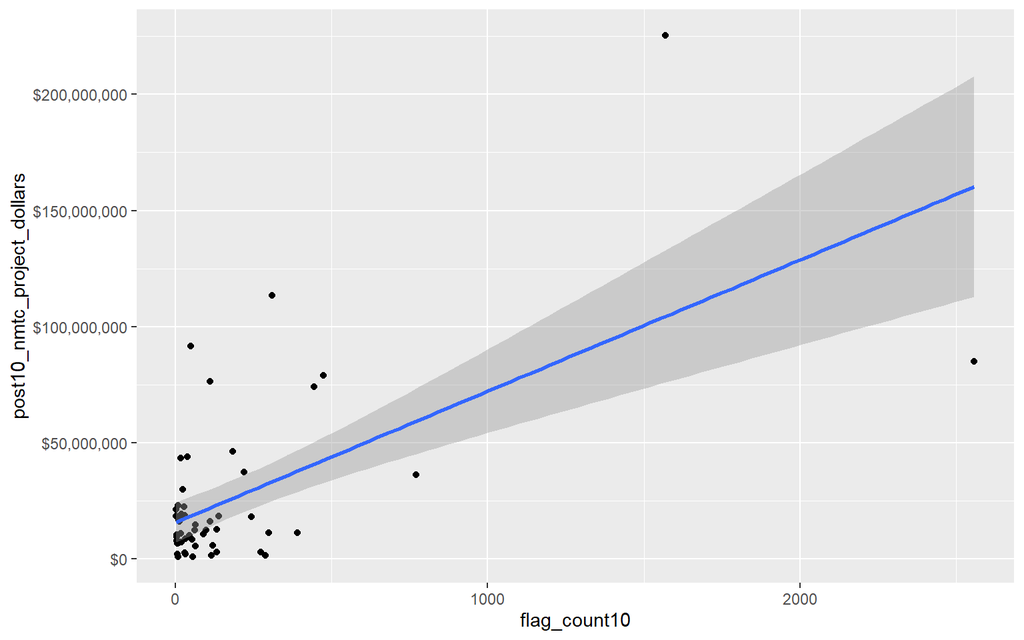

```r
# Scatterplot
# y is our independent variable (NMTC Project Dollars),
# x is our dependent variable (SVI flag count)
ggplot2::ggplot(svi_divisional_county_nmtc_projects,
                aes(x=flag_count10,
                    y=post10_nmtc_project_dollars)) +
        geom_point() +
        geom_smooth(method="lm") +
        scale_y_continuous(labels = scales::dollar_format())
```

Here we can also see several outliers that are skewing the medians of our data.

### Correlation between flag count and NMTC dollars spent within counties

```r
# Pearson's r calculation
cor(svi_divisional_county_nmtc_projects$flag_count10, svi_divisional_county_nmtc_projects$post10_nmtc_project_dollars, method = "pearson")
```

```
## [1] 0.6174326
```

A Pearson’s R calculation of 0.62 suggests that there is a strong positive association between the dollar amount spent in NMTC from 2011-2020 and the flag count within the Mountain Division counties in 2010.

Let’s look at a box plot to examine this further:

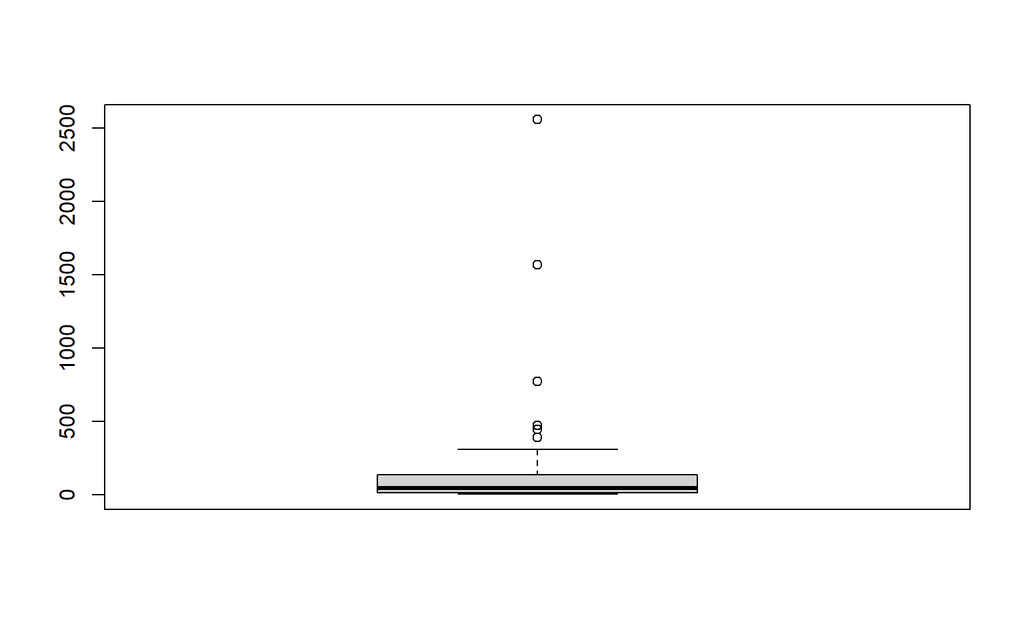

```r
boxplot(svi_divisional_county_nmtc_projects$flag_count10)
```

```r
boxplot.stats(svi_divisional_county_nmtc_projects$flag_count10)$out %>% sort(decreasing = TRUE)
```

```
## [1] 2558 1569  771  473  444  390
```

The boxplot shows most of our data lies within the lower quadrant of flag counts. Additionally, there are 6 outliers identified. There are identified here:

```r
svi_divisional_county_nmtc_projects %>%
  select(county_name, flag_count10, post10_nmtc_dollars_formatted) %>%
  arrange(desc(flag_count10)) %>%
  head(6) %>% kbl() %>% kable_styling() %>% scroll_box(width = "100%")
```

| county_name | flag_count10 | post10_nmtc_dollars_formatted |
| --- | --- | --- |
| Maricopa County, AZ | 2558 | $84,923,464 |
| Clark County, NV | 1569 | $225,315,967 |
| Pima County, AZ | 771 | $36,122,128 |
| Denver County, CO | 473 | $78,905,000 |
| Bernalillo County, NM | 444 | $74,237,755 |
| Adams County, CO | 390 | $11,168,200 |

Let’s examine our major outlier, Maricopa County, AZ data point further:

```r
svi_divisional_nmtc %>% filter(county == "Maricopa County") %>% select(GEOID_2010_trt, F_TOTAL_10, post10_nmtc_dollars) %>% summary()
```

```
##  GEOID_2010_trt       F_TOTAL_10     post10_nmtc_dollars
##  Length:322         Min.   : 1.000   Min.   :       0
##  Class :character   1st Qu.: 5.000   1st Qu.:       0
##  Mode  :character   Median : 9.000   Median :       0
##                     Mean   : 7.944   Mean   :  263737
##                     3rd Qu.:11.000   3rd Qu.:       0
##                     Max.   :14.000   Max.   :22900000
```

### K-Means Clustering

```r
svi_divisional_nmtc_cluster <- svi_divisional_county_nmtc_projects %>%
                            select(county_name, post10_nmtc_project_dollars,
                                   flag_count10) %>%
                            remove_rownames %>%
                            column_to_rownames(var="county_name")

# Remove nulls, if in dataset
svi_divisional_nmtc_cluster <- na.omit(svi_divisional_nmtc_cluster)


# Scale numeric variables
svi_divisional_nmtc_cluster <- scale(svi_divisional_nmtc_cluster)


svi_divisional_nmtc_cluster %>% head(5)
```

```
##                     post10_nmtc_project_dollars flag_count10
## Apache County, AZ                    -0.3541120   -0.1073628
## Gila County, AZ                      -0.5466172   -0.2773136
## Maricopa County, AZ                   1.5935295    5.8655464
## Navajo County, AZ                     0.5497734    0.0182530
## Pima County, AZ                       0.2803462    1.4640665
```

```r
set.seed(123)
k2_nmtc_div <- kmeans(svi_divisional_nmtc_cluster, centers = 2, nstart = 25)
set.seed(123)
k3_nmtc_div <- kmeans(svi_divisional_nmtc_cluster, centers = 3, nstart = 25)
set.seed(123)
k4_nmtc_div <- kmeans(svi_divisional_nmtc_cluster, centers = 4, nstart = 25)
set.seed(123)
k5_nmtc_div <- kmeans(svi_divisional_nmtc_cluster, centers = 5, nstart = 25)
```

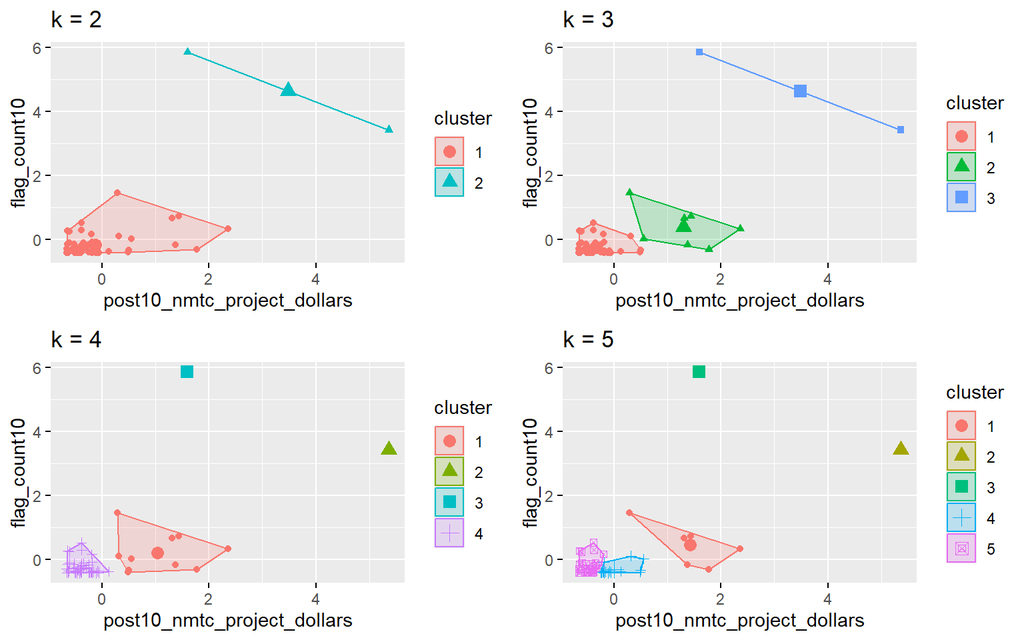

```r
# plots to compare
p_k2_nmtc_div <- factoextra::fviz_cluster(k2_nmtc_div, geom = "point", data = svi_divisional_nmtc_cluster) + ggtitle("k = 2")

p_k3_nmtc_div <- factoextra::fviz_cluster(k3_nmtc_div, geom = "point", data = svi_divisional_nmtc_cluster) + ggtitle("k = 3")

p_k4_nmtc_div <- factoextra::fviz_cluster(k4_nmtc_div, geom = "point",  data = svi_divisional_nmtc_cluster) + ggtitle("k = 4")

p_k5_nmtc_div <- factoextra::fviz_cluster(k5_nmtc_div, geom = "point",  data = svi_divisional_nmtc_cluster) + ggtitle("k = 5")

grid.arrange(p_k2_nmtc_div, p_k3_nmtc_div, p_k4_nmtc_div, p_k5_nmtc_div, nrow = 2)
```

In visually inspecting our plots, it appears that k=3 has the best grouping to the eye, with no overlap in the groups.

[output not shown]

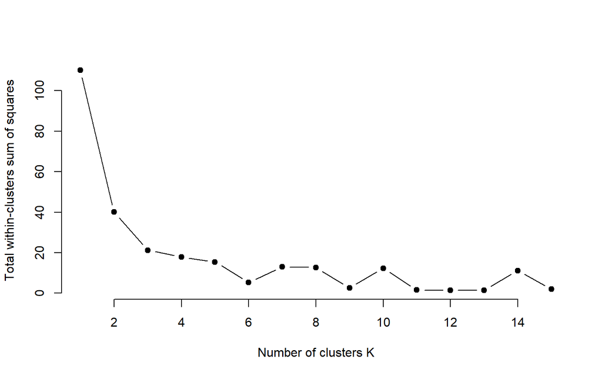

```r
elbow_plot(svi_divisional_nmtc_cluster)
```

In looking at our elbow plot, it appears that there is not much variation between point 3 and 4. This aligns well with our visual observation.

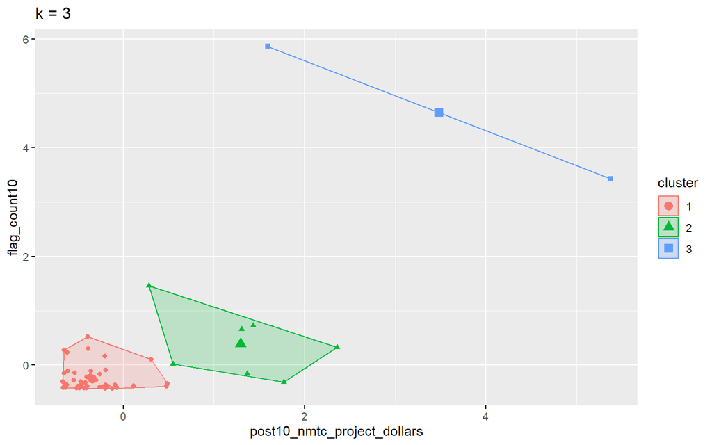

```r
p_k3_nmtc_div <- factoextra::fviz_cluster(k3_nmtc_div, geom = "point", data = svi_divisional_nmtc_cluster) + ggtitle("k = 3")

p_k3_nmtc_div
```

Here we will assign these 3 clusters to our county data set:

```r
svi_divisional_nmtc_cluster_label <- as.data.frame(svi_divisional_nmtc_cluster) %>%
                                  rownames_to_column(var = "county_name") %>%
                                  as_tibble() %>%
                                  mutate(cluster = k3_nmtc_div$cluster) %>%
                                  select(county_name, cluster)

svi_divisional_county_nmtc_projects2 <- left_join(svi_divisional_county_nmtc_projects, svi_divisional_nmtc_cluster_label, join_by(county_name == county_name))

# View county counts in each cluster
table(svi_divisional_county_nmtc_projects2$cluster)
```

```
##
##  1  2  3
## 47  7  2
```

**Cluster 1**

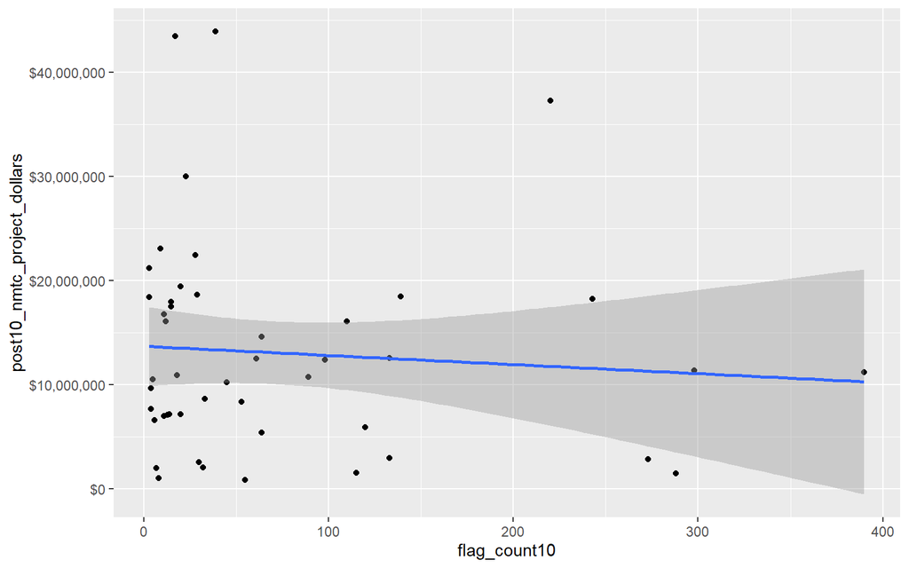

```r
# Cluster 1 Scatterplot
# y is our independent variable (NMTC Project Dollars),
# x is our dependent variable (SVI flag count)

svi_divisional_county_nmtc_projects2 %>%
  filter(cluster == 1) %>%
  ggplot2::ggplot(aes(x=flag_count10,
                    y=post10_nmtc_project_dollars)) +
        geom_point() +
        geom_smooth(method="lm") +
        scale_y_continuous(labels = scales::dollar_format())
```

```r
svi_divisional_county_nmtc_projects2 %>%
  filter(cluster == 1) %>%
  select(flag_count10,post10_nmtc_project_dollars) %>%
  cor(method = "pearson")
```

```
##                             flag_count10 post10_nmtc_project_dollars
## flag_count10                  1.00000000                 -0.07984396
## post10_nmtc_project_dollars  -0.07984396                  1.00000000
```

This cluster contains the majority of our counties that received NMTC funding and shows a very weak negative, or no association correlation between flag counts from 2010 census data and money received the following decade from NMTC.

Here are the counties that fall into cluster 1:

```r
svi_divisional_county_nmtc_projects2 %>%
  filter(cluster == 1) %>%
  select(county_name, flag_count10, post10_nmtc_dollars_formatted) %>% kbl() %>% kable_styling() %>% scroll_box(width = "100%")
```

| county_name | flag_count10 | post10_nmtc_dollars_formatted |
| --- | --- | --- |
| Apache County, AZ | 133 | $12,544,000 |
| Gila County, AZ | 64 | $5,390,000 |
| Pinal County, AZ | 220 | $37,224,559 |
| Yuma County, AZ | 288 | $1,454,000 |
| Adams County, CO | 390 | $11,168,200 |
| Arapahoe County, CO | 298 | $11,357,669 |
| Archuleta County, CO | 7 | $1,950,000 |
| Boulder County, CO | 115 | $1,500,000 |
| Delta County, CO | 8 | $1,009,700 |
| Jefferson County, CO | 120 | $5,880,000 |
| Larimer County, CO | 98 | $12,340,000 |
| Mesa County, CO | 55 | $800,000 |
| Washington County, CO | 4 | $9,640,000 |
| Bannock County, ID | 28 | $22,425,000 |
| Madison County, ID | 17 | $43,440,000 |
| Valley County, ID | 3 | $21,148,000 |
| Big Horn County, MT | 33 | $8,624,000 |
| Cascade County, MT | 45 | $10,189,000 |
| Chouteau County, MT | 4 | $7,663,000 |
| Gallatin County, MT | 11 | $6,960,000 |
| Glacier County, MT | 20 | $7,129,500 |
| Hill County, MT | 13 | $7,081,000 |
| Lake County, MT | 11 | $16,715,500 |
| Lewis and Clark County, MT | 9 | $23,069,500 |
| Missoula County, MT | 15 | $17,945,000 |
| Roosevelt County, MT | 14 | $7,104,000 |
| Silver Bow County, MT | 12 | $16,056,000 |
| Yellowstone County, MT | 39 | $43,880,900 |
| Chaves County, NM | 64 | $14,550,000 |
| Dona Ana County, NM | 243 | $18,187,500 |
| Eddy County, NM | 20 | $19,400,000 |
| McKinley County, NM | 139 | $18,460,000 |
| San Juan County, NM | 89 | $10,690,000 |
| San Miguel County, NM | 53 | $8,330,000 |
| Sandoval County, NM | 61 | $12,480,000 |
| Santa Fe County, NM | 110 | $16,045,000 |
| Douglas County, NV | 5 | $10,500,000 |
| Elko County, NV | 23 | $30,000,000 |
| Lyon County, NV | 30 | $2,520,000 |
| Nye County, NV | 32 | $2,000,000 |
| Washoe County, NV | 273 | $2,810,000 |
| Grand County, UT | 3 | $18,378,750 |
| Iron County, UT | 29 | $18,625,000 |
| Utah County, UT | 133 | $2,950,000 |
| Albany County, WY | 15 | $17,460,000 |
| Fremont County, WY | 18 | $10,874,750 |
| Goshen County, WY | 6 | $6,556,800 |

**Cluster 2**

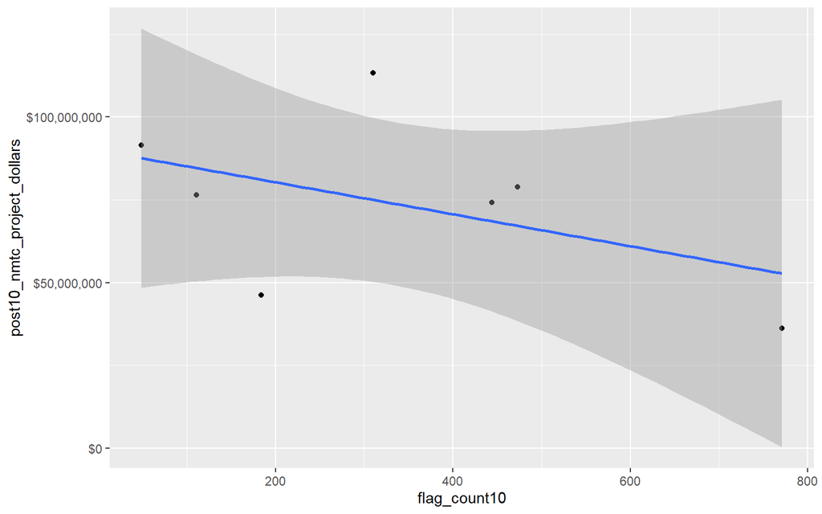

```r
# Cluster 2 Scatterplot
# y is our independent variable (NMTC Project Dollars),
# x is our dependent variable (SVI flag count)

svi_divisional_county_nmtc_projects2 %>%
  filter(cluster == 2) %>%
  ggplot2::ggplot(aes(x=flag_count10,
                    y=post10_nmtc_project_dollars)) +
        geom_point() +
        geom_smooth(method="lm") +
        scale_y_continuous(labels = scales::dollar_format())
```

**Cluster 2**

```r
svi_divisional_county_nmtc_projects2 %>%
  filter(cluster == 2) %>%
  select(flag_count10,post10_nmtc_project_dollars) %>%
  cor(method = "pearson")
```

```
##                             flag_count10 post10_nmtc_project_dollars
## flag_count10                    1.000000                   -0.462471
## post10_nmtc_project_dollars    -0.462471                    1.000000
```

This cluster group contained only 7 data points, and shows a moderate negative correlation (Pearson’s R of -0.46) between flag count in 2010 and NMTC money received the following decade.

These are our Cluster 2 counties:

```r
svi_divisional_county_nmtc_projects2 %>%
  filter(cluster == 2) %>%
  select(county_name, flag_count10, post10_nmtc_dollars_formatted)
```

```
##             county_name flag_count10 post10_nmtc_dollars_formatted
## 1     Navajo County, AZ          184                   $46,134,750
## 2       Pima County, AZ          771                   $36,122,128
## 3     Denver County, CO          473                   $78,905,000
## 4     Canyon County, ID          111                   $76,432,000
## 5 Bernalillo County, NM          444                   $74,237,755
## 6     Cibola County, NM           49                   $91,548,630
## 7  Salt Lake County, UT          310                  $113,282,833
```

**Cluster 3**

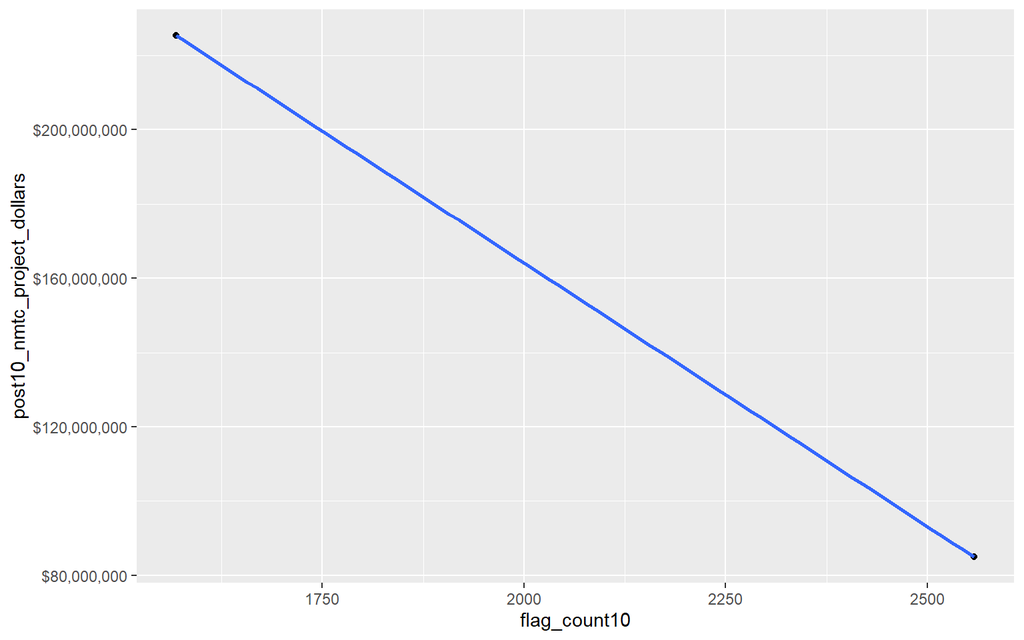

```r
# Cluster 3 Scatterplot
# y is our independent variable (NMTC Project Dollars),
# x is our dependent variable (SVI flag count)

svi_divisional_county_nmtc_projects2 %>%
  filter(cluster == 3) %>%
  ggplot2::ggplot(aes(x=flag_count10,
                    y=post10_nmtc_project_dollars)) +
        geom_point() +
        geom_smooth(method="lm") +
        scale_y_continuous(labels = scales::dollar_format())
```

```r
svi_divisional_county_nmtc_projects2 %>%
  filter(cluster == 3) %>%
  select(flag_count10,post10_nmtc_project_dollars) %>%
  cor(method = "pearson")
```

```
##                             flag_count10 post10_nmtc_project_dollars
## flag_count10                           1                          -1
## post10_nmtc_project_dollars           -1                           1
```

In looking at our correlation for cluster 3 which contain our outliers, a Pearson’s R score of -1 shows a high negative correlation within our cluster between flag count and money received in these 2 counties. However, we know that there are only 2 data points in this cluster.

These are the 2 counties in Cluster 3:

```r
svi_divisional_county_nmtc_projects2 %>%
  filter(cluster == 3) %>%
  select(county_name, flag_count10, post10_nmtc_dollars_formatted)
```

```
##           county_name flag_count10 post10_nmtc_dollars_formatted
## 1 Maricopa County, AZ         2558                   $84,923,464
## 2    Clark County, NV         1569                  $225,315,967
```

**Overall, if we look at cluster 1, we see that it contains the majority of our data. It also shows that for the majority of our data points, there is almost no correlation between the amount of money received in NMTC and the SVI vulnerability flag count.**

### Bivariate Mapping

```r
divisional_county_sf <- svi_county_map2010 %>% select(COUNTYFP, STATEFP, geometry)

divisional_county_sf %>% head(5)
```

```
## Simple feature collection with 5 features and 2 fields
## Geometry type: MULTIPOLYGON
## Dimension:     XY
## Bounding box:  xmin: -113.3542 ymin: 31.3325 xmax: -109.0452 ymax: 37.0032
## Geodetic CRS:  NAD83
##   COUNTYFP STATEFP                       geometry
## 1      001      04 MULTIPOLYGON (((-109.0464 3...
## 2      003      04 MULTIPOLYGON (((-110.0031 3...
## 3      005      04 MULTIPOLYGON (((-112.3754 3...
## 4      007      04 MULTIPOLYGON (((-111.2865 3...
## 5      009      04 MULTIPOLYGON (((-110.4486 3...
```

```r
# Join our NMTC projects data with our shapefile geocoordinates
svi_divisional_county_nmtc_sf <- left_join(svi_divisional_county_nmtc_projects, divisional_county_sf, join_by("FIPS_st" == "STATEFP", "FIPS_county" == "COUNTYFP"))

svi_divisional_county_nmtc_sf %>% head(5) %>% kbl() %>% kable_styling() %>% scroll_box(width = "100%")
```

| State | County | Division | post10_nmtc_project_cnt | tract_cnt | post10_nmtc_project_dollars | post10_nmtc_dollars_formatted | fips_county_st | FIPS_st | FIPS_county | state_name | region_number | region | division_number | flag_count10 | pop10 | flag_by_pop10 | flag_count_quantile10 | flag_pop_quantile10 | flag_count20 | pop20 | flag_by_pop20 | flag_count_quantile20 | flag_pop_quantile20 | county_name | geometry |
| --- | --- | --- | --- | --- | --- | --- | --- | --- | --- | --- | --- | --- | --- | --- | --- | --- | --- | --- | --- | --- | --- | --- | --- | --- | --- |
| AZ | Apache County | Mountain Division | 1 | 14 | 12544000 | $12,544,000 | 04001 | 04 | 001 | Arizona | 4 | West Region | 8 | 133 | 62408 | 0.0021311 | 1 | 0.8 | 124 | 62852 | 0.0019729 | 1 | 0.8 | Apache County, AZ | MULTIPOLYGON (((-109.0464 3… |
| AZ | Gila County | Mountain Division | 1 | 11 | 5390000 | $5,390,000 | 04007 | 04 | 007 | Arizona | 4 | West Region | 8 | 64 | 31239 | 0.0020487 | 1 | 0.8 | 72 | 31645 | 0.0022752 | 1 | 1.0 | Gila County, AZ | MULTIPOLYGON (((-111.2865 3… |
| AZ | Maricopa County | Mountain Division | 15 | 322 | 84923464 | $84,923,464 | 04013 | 04 | 013 | Arizona | 4 | West Region | 8 | 2558 | 1355508 | 0.0018871 | 1 | 0.8 | 2457 | 1547710 | 0.0015875 | 1 | 0.6 | Maricopa County, AZ | MULTIPOLYGON (((-112.9158 3… |
| AZ | Navajo County | Mountain Division | 2 | 24 | 46134750 | $46,134,750 | 04017 | 04 | 017 | Arizona | 4 | West Region | 8 | 184 | 83885 | 0.0021935 | 1 | 1.0 | 200 | 87599 | 0.0022831 | 1 | 1.0 | Navajo County, AZ | MULTIPOLYGON (((-110.7021 3… |
| AZ | Pima County | Mountain Division | 7 | 104 | 36122128 | $36,122,128 | 04019 | 04 | 019 | Arizona | 4 | West Region | 8 | 771 | 433051 | 0.0017804 | 1 | 0.8 | 826 | 439374 | 0.0018799 | 1 | 0.8 | Pima County, AZ | MULTIPOLYGON (((-112.3881 3… |

```r
# Create classes for bivariate mapping
svi_divisional_county_nmtc_sf <- bi_class(svi_divisional_county_nmtc_sf, x = flag_count10, y = post10_nmtc_project_dollars, style = "quantile", dim = 3)

# View data
svi_divisional_county_nmtc_sf %>% head(5) %>% kbl() %>% kable_styling() %>% scroll_box(width = "100%")
```

| State | County | Division | post10_nmtc_project_cnt | tract_cnt | post10_nmtc_project_dollars | post10_nmtc_dollars_formatted | fips_county_st | FIPS_st | FIPS_county | state_name | region_number | region | division_number | flag_count10 | pop10 | flag_by_pop10 | flag_count_quantile10 | flag_pop_quantile10 | flag_count20 | pop20 | flag_by_pop20 | flag_count_quantile20 | flag_pop_quantile20 | county_name | geometry | bi_class |
| --- | --- | --- | --- | --- | --- | --- | --- | --- | --- | --- | --- | --- | --- | --- | --- | --- | --- | --- | --- | --- | --- | --- | --- | --- | --- | --- |
| AZ | Apache County | Mountain Division | 1 | 14 | 12544000 | $12,544,000 | 04001 | 04 | 001 | Arizona | 4 | West Region | 8 | 133 | 62408 | 0.0021311 | 1 | 0.8 | 124 | 62852 | 0.0019729 | 1 | 0.8 | Apache County, AZ | MULTIPOLYGON (((-109.0464 3… | 3-2 |
| AZ | Gila County | Mountain Division | 1 | 11 | 5390000 | $5,390,000 | 04007 | 04 | 007 | Arizona | 4 | West Region | 8 | 64 | 31239 | 0.0020487 | 1 | 0.8 | 72 | 31645 | 0.0022752 | 1 | 1.0 | Gila County, AZ | MULTIPOLYGON (((-111.2865 3… | 2-1 |
| AZ | Maricopa County | Mountain Division | 15 | 322 | 84923464 | $84,923,464 | 04013 | 04 | 013 | Arizona | 4 | West Region | 8 | 2558 | 1355508 | 0.0018871 | 1 | 0.8 | 2457 | 1547710 | 0.0015875 | 1 | 0.6 | Maricopa County, AZ | MULTIPOLYGON (((-112.9158 3… | 3-3 |
| AZ | Navajo County | Mountain Division | 2 | 24 | 46134750 | $46,134,750 | 04017 | 04 | 017 | Arizona | 4 | West Region | 8 | 184 | 83885 | 0.0021935 | 1 | 1.0 | 200 | 87599 | 0.0022831 | 1 | 1.0 | Navajo County, AZ | MULTIPOLYGON (((-110.7021 3… | 3-3 |
| AZ | Pima County | Mountain Division | 7 | 104 | 36122128 | $36,122,128 | 04019 | 04 | 019 | Arizona | 4 | West Region | 8 | 771 | 433051 | 0.0017804 | 1 | 0.8 | 826 | 439374 | 0.0018799 | 1 | 0.8 | Pima County, AZ | MULTIPOLYGON (((-112.3881 3… | 3-3 |

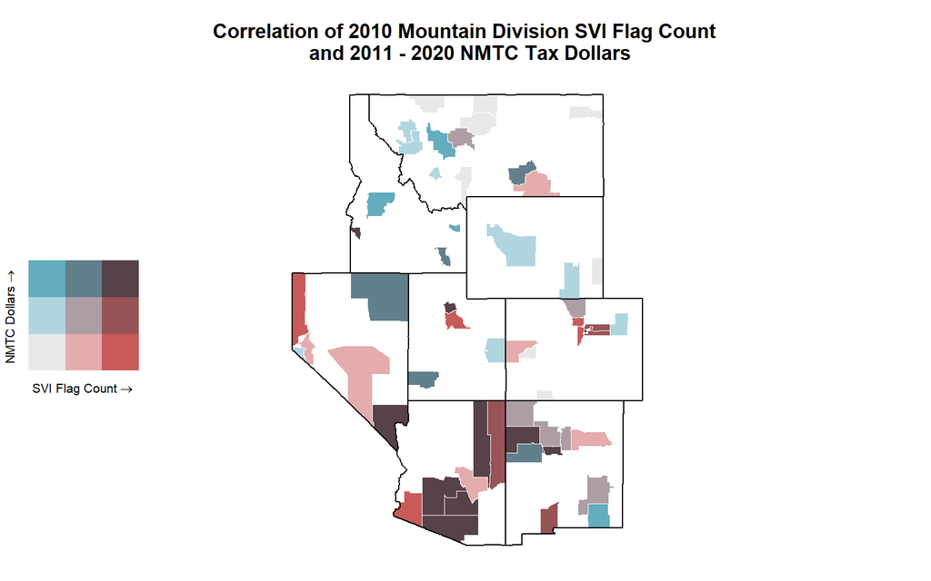

```r
# Create map with ggplot
svi_divisional_county_nmtc_map <- ggplot() +
  # Map county shapefile, fill with bi_class categories
  geom_sf(data = svi_divisional_county_nmtc_sf, mapping = aes(geometry=geometry, fill = bi_class), color = "white", size = 0.1, show.legend = FALSE) +
  # Set to biscale palette
  bi_scale_fill(pal = "GrPink", dim = 3) +
  # Add state shapefiles for outline
  geom_sf(data=divisional_st_sf, color="black", fill=NA, linewidth=.5, aes(geometry=geometry)) +
  labs(
    title = paste0("Correlation of 2010 ", census_division, " SVI Flag Count \n and 2011 - 2020 NMTC Tax Dollars"),
  ) +
  # Set them to biscale
  bi_theme(base_size = 10)

# Create biscale legend
svi_divisional_county_nmtc_legend <- bi_legend(pal = "GrPink",
                    dim = 3,
                    xlab = "SVI Flag Count",
                    ylab = "NMTC Dollars",
                    size = 8)

# Combine map with legend using cowplot
svi_divisional_county_nmtc_bivarmap <- ggdraw() +
  draw_plot(svi_divisional_county_nmtc_map) +
  # Set legend location
  draw_plot(svi_divisional_county_nmtc_legend, x= -.02,  y = -.05,
 width=.20)


# View map
svi_divisional_county_nmtc_bivarmap
```

Here we can see the distribution of SVI flag counts and NMTC dollars spent in each county receiving funds. Montana, Idaho, and Wyoming received high dollars compared to low flag counts, indicated by the blue color.

```r
svi_divisional_county_nmtc_sf %>% filter(State %in% c("MT", "ID", "WY")) %>%
  arrange(desc(post10_nmtc_project_dollars), flag_count10) %>% select(State, County, flag_count10, post10_nmtc_dollars_formatted) %>% head(10)
```

```
##    State                 County flag_count10 post10_nmtc_dollars_formatted
## 1     ID          Canyon County          111                   $76,432,000
## 2     MT     Yellowstone County           39                   $43,880,900
## 3     ID         Madison County           17                   $43,440,000
## 4     MT Lewis and Clark County            9                   $23,069,500
## 5     ID         Bannock County           28                   $22,425,000
## 6     ID          Valley County            3                   $21,148,000
## 7     MT        Missoula County           15                   $17,945,000
## 8     WY          Albany County           15                   $17,460,000
## 9     MT            Lake County           11                   $16,715,500
## 10    MT      Silver Bow County           12                   $16,056,000
```

Nevada received the most dollars in the highest need counties, indicated by the purple dark purple color.

```r
svi_divisional_county_nmtc_sf %>% filter(State %in% c("NV", "NM")) %>% select(State, County, flag_count10, post10_nmtc_dollars_formatted) %>% arrange(desc(flag_count10)) %>% head(10)
```

```
##    State            County flag_count10 post10_nmtc_dollars_formatted
## 1     NV      Clark County         1569                  $225,315,967
## 2     NM Bernalillo County          444                   $74,237,755
## 3     NV     Washoe County          273                    $2,810,000
## 4     NM   Dona Ana County          243                   $18,187,500
## 5     NM   McKinley County          139                   $18,460,000
## 6     NM   Santa Fe County          110                   $16,045,000
## 7     NM   San Juan County           89                   $10,690,000
## 8     NM     Chaves County           64                   $14,550,000
## 9     NM   Sandoval County           61                   $12,480,000
## 10    NM San Miguel County           53                    $8,330,000
```

## 2010 Low Income Housing Tax Credit Mountain Division

```r
svi_divisional_county_lihtc_projects <- svi_divisional_county_lihtc %>% filter(post10_lihtc_project_cnt > 0)

svi_divisional_county_lihtc_projects %>% select(Division) %>% unique()
```

```
##            Division
## 1 Mountain Division
```

### Data Summary Statistics

```r
summary(svi_divisional_county_lihtc_projects$flag_count10)
```

```
##    Min. 1st Qu.  Median    Mean 3rd Qu.    Max.
##    9.00   15.50   21.00   67.33   56.50  487.00
```

```r
summary(svi_divisional_county_lihtc_projects$post10_lihtc_project_dollars)
```

```
##     Min.  1st Qu.   Median     Mean  3rd Qu.     Max.
##        0   674696  1721391  3350971  3203130 15437500
```

Filter out counties with LIHTC projects but did not receive any funding:

```r
svi_divisional_county_lihtc_projects <- svi_divisional_county_lihtc_projects %>% filter(post10_lihtc_project_dollars > 0)
```

```r
summary(svi_divisional_county_lihtc_projects$flag_count10)
```

```
##    Min. 1st Qu.  Median    Mean 3rd Qu.    Max.
##    9.00   14.75   21.00   64.64   33.75  487.00
```

```r
summary(svi_divisional_county_lihtc_projects$post10_lihtc_project_dollars)
```

```
##     Min.  1st Qu.   Median     Mean  3rd Qu.     Max.
##   270127   817782  1836756  3590326  3380196 15437500
```

The Mountain division counties receiving LIHTC project funding between 2011-2020, had a range of 9 to 487 SVI flags in 2010. The funding amounts ranged from $270,127 and $15,437,500. There is a large range between counties in the number of SVI flags in 2010 and funding dollars spent between 2011 and 2020.

Let’s view this data visually in a scatterplot:

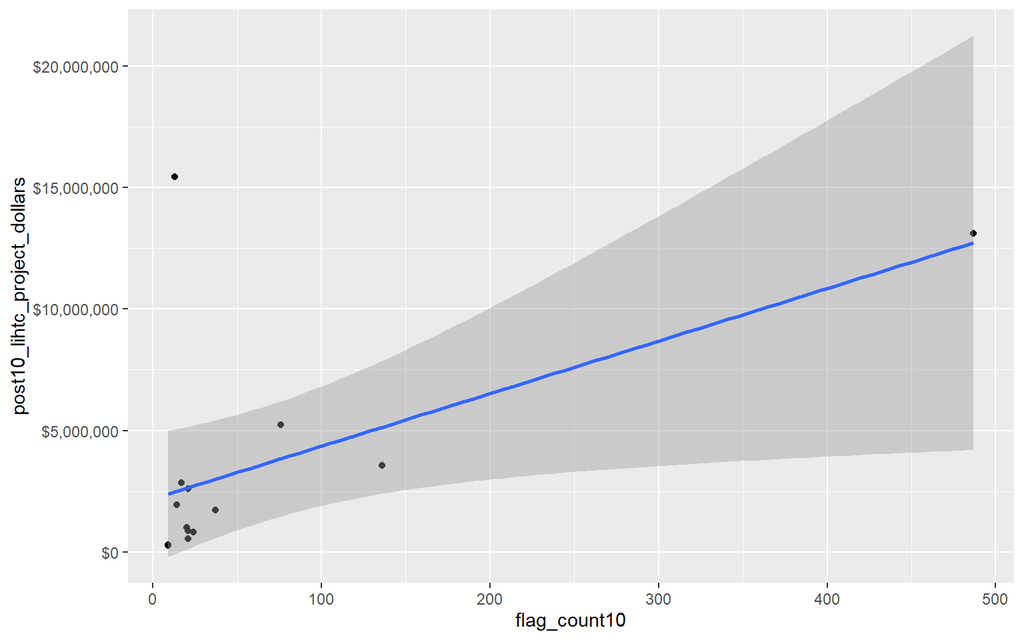

```r
# Scatterplot
# y is our independent variable (LIHTC Project Dollars),
# x is our dependent variable (SVI flag count)
ggplot2::ggplot(svi_divisional_county_lihtc_projects,
                aes(x=flag_count10,
                    y=post10_lihtc_project_dollars)) +
        geom_point() +
        geom_smooth(method="lm") +
        scale_y_continuous(labels = scales::dollar_format())
```

Here we can see 1 outlier in dollars spent.

### Pearson’s R Correlation between SVI flag count and LIHTC dollars spent

```r
# Pearson's r calculation
cor(svi_divisional_county_lihtc_projects$flag_count10, svi_divisional_county_lihtc_projects$post10_lihtc_project_dollars, method = "pearson")
```

```
## [1] 0.5743274
```

Overall, within all the counties in the Mountain Division, there is a moderate positive correlation between SVI flags from 2010 and dollars spent on LIHTC in 2011-2020, with a Pearson’s score of 0.57.

Here is a boxplot of this data:

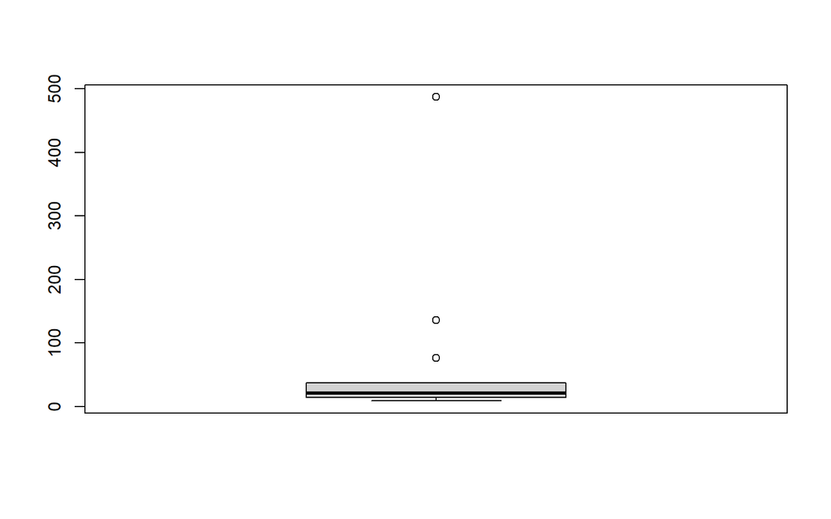

```r
boxplot(svi_divisional_county_lihtc_projects$flag_count10)
```

Here we can see three outliers, with high flag counts:

```r
boxplot.stats(svi_divisional_county_lihtc_projects$flag_count10)$out %>% sort(decreasing = TRUE)
```

```
## [1] 487 136  76
```

```r
svi_divisional_county_lihtc_projects %>% filter(flag_count10 == 487) %>% select(county_name, flag_count10, post10_lihtc_dollars_formatted) %>% head()
```

```
##           county_name flag_count10 post10_lihtc_dollars_formatted
## 1 Maricopa County, AZ          487                    $13,115,292
```

Again, we can see that Maricopa County is also an outlier in flag counts.

### K-Means Clustering

```r
svi_divisional_lihtc_cluster <- svi_divisional_county_lihtc_projects %>%
                            select(county_name, post10_lihtc_project_dollars,
                                   flag_count10) %>%
                            remove_rownames %>%
                            column_to_rownames(var="county_name")

# Remove nulls, if in dataset
svi_divisional_lihtc_cluster <- na.omit(svi_divisional_lihtc_cluster)


# Scale numeric variables
svi_divisional_lihtc_cluster <- scale(svi_divisional_lihtc_cluster)


svi_divisional_lihtc_cluster %>% head(5)
```

```
##                     post10_lihtc_project_dollars flag_count10
## Gila County, AZ                     -0.639463325  -0.34550646
## Maricopa County, AZ                  2.001527998   3.34366562
## Pima County, AZ                     -0.006948156   0.56491154
## Yuma County, AZ                     -0.572769441  -0.34550646
## Denver County, CO                    0.343739090   0.08991085
```

Let’s look at different cluster groupings:

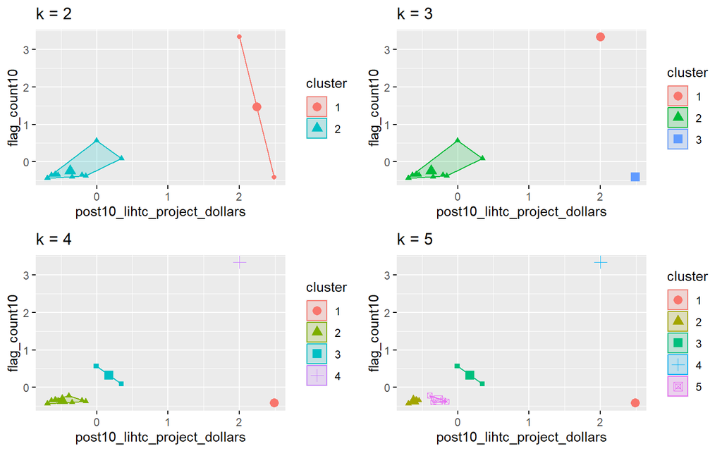

```r
set.seed(123)
k2_lihtc_div <- kmeans(svi_divisional_lihtc_cluster, centers = 2, nstart = 25)
set.seed(123)
k3_lihtc_div <- kmeans(svi_divisional_lihtc_cluster, centers = 3, nstart = 25)
set.seed(123)
k4_lihtc_div <- kmeans(svi_divisional_lihtc_cluster, centers = 4, nstart = 25)
set.seed(123)
k5_lihtc_div <- kmeans(svi_divisional_lihtc_cluster, centers = 5, nstart = 25)


# plots to compare
p_k2_lihtc_div <- factoextra::fviz_cluster(k2_lihtc_div, geom = "point", data = svi_divisional_lihtc_cluster) + ggtitle("k = 2")

p_k3_lihtc_div <- factoextra::fviz_cluster(k3_lihtc_div, geom = "point", data = svi_divisional_lihtc_cluster) + ggtitle("k = 3")

p_k4_lihtc_div <- factoextra::fviz_cluster(k4_lihtc_div, geom = "point",  data = svi_divisional_lihtc_cluster) + ggtitle("k = 4")

p_k5_lihtc_div <- factoextra::fviz_cluster(k5_lihtc_div, geom = "point",  data = svi_divisional_lihtc_cluster) + ggtitle("k = 5")

grid.arrange(p_k2_lihtc_div, p_k3_lihtc_div, p_k4_lihtc_div, p_k5_lihtc_div, nrow = 2)
```

Visually, 2 clusters looks to capture our data points best, but we can check an elbow plot:

```
##  [1]  1  2  3  4  5  6  7  8  9 10 11 12 13
## [1] 1
## [1] 2
## [1] 3
## [1] 4
## [1] 5
## [1] 6
## [1] 7
## [1] 8
## [1] 9
## [1] 10
## [1] 11
## [1] 12
## [1] 13
```

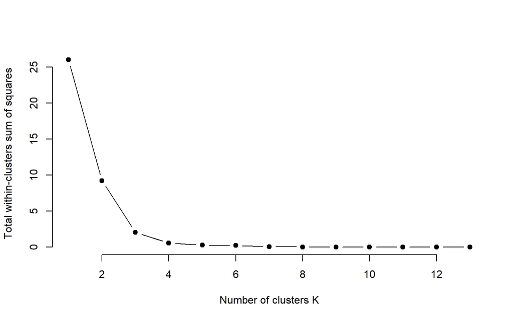

```r
elbow_plot(svi_divisional_lihtc_cluster)
```

This elbow plot shows that 3 clusters makes sense, as the spacing does not decrease until after point 3. I will choose to use three clusters for the LIHTC data for the Mountain Division:

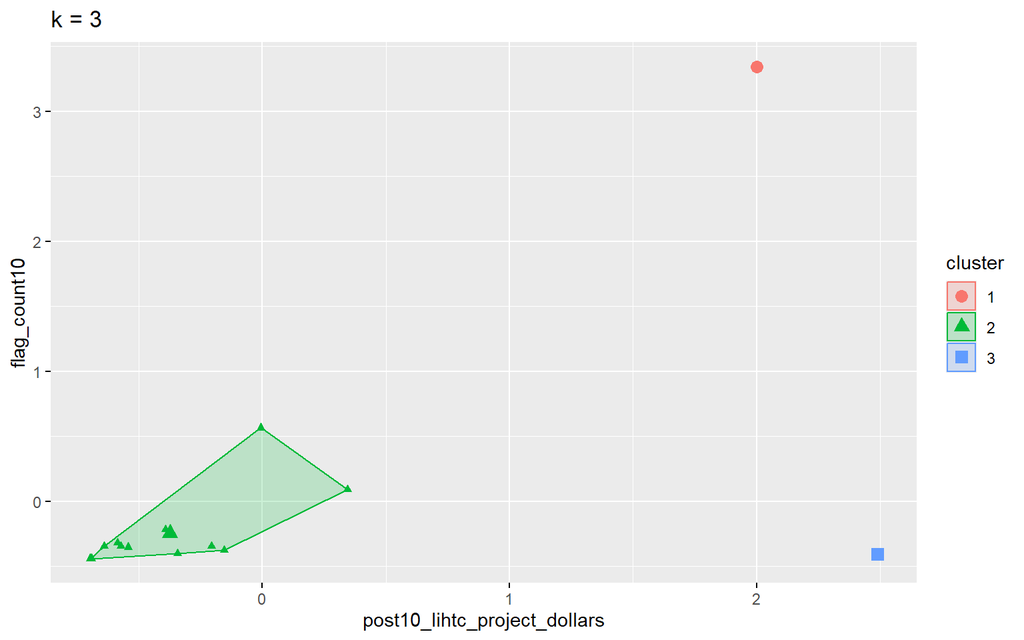

```r
p_k3_lihtc_div <- factoextra::fviz_cluster(k3_lihtc_div, geom = "point", data = svi_divisional_lihtc_cluster) + ggtitle("k = 3")

p_k3_lihtc_div
```

Let’s assign these clusters to our county data:

```r
svi_divisional_lihtc_cluster_label <- as.data.frame(svi_divisional_lihtc_cluster) %>%
                                  rownames_to_column(var = "county_name") %>%
                                  as_tibble() %>%
                                  mutate(cluster = k3_lihtc_div$cluster) %>%
                                  select(county_name, cluster)

svi_divisional_county_lihtc_projects2 <- left_join(svi_divisional_county_lihtc_projects, svi_divisional_lihtc_cluster_label, join_by(county_name == county_name))

# View county counts in each cluster
table(svi_divisional_county_lihtc_projects2$cluster)
```

```
##
##  1  2  3
##  1 12  1
```

Again this was our scatterplot and Pearson’s R for the overall data:

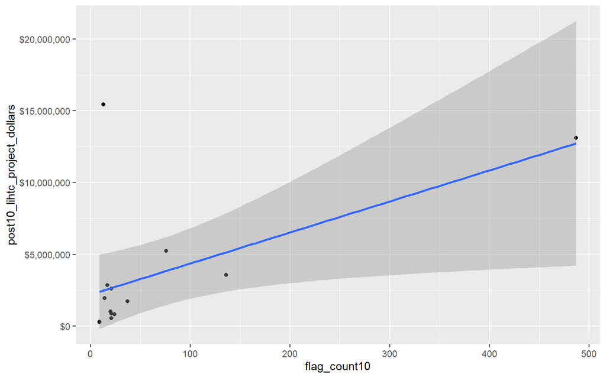

```r
# Overall Scatterplot
# y is our independent variable (LIHTC Project Dollars),
# x is our dependent variable (SVI flag count)
ggplot2::ggplot(svi_divisional_county_lihtc_projects2,
                aes(x=flag_count10,
                    y=post10_lihtc_project_dollars)) +
        geom_point() +
        geom_smooth(method="lm") +
        scale_y_continuous(labels = scales::dollar_format())
```

```r
# Pearson's r calculation
cor(svi_divisional_county_lihtc_projects2$flag_count10, svi_divisional_county_lihtc_projects2$post10_lihtc_project_dollars, method = "pearson")
```

```
## [1] 0.5743274
```

**Cluster 1**

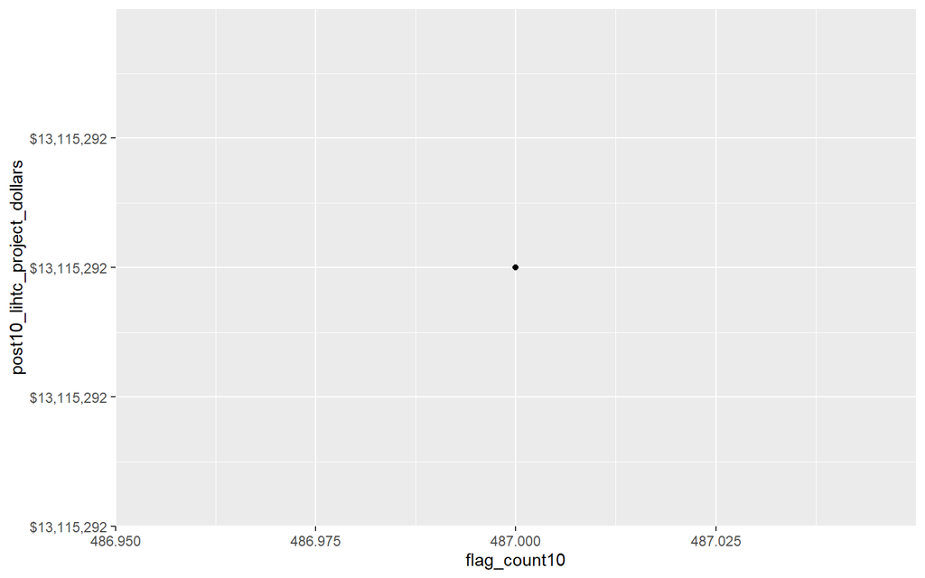

```r
# Cluster 1 Scatterplot
# y is our independent variable (LIHTC Project Dollars),
# x is our dependent variable (SVI flag count)

svi_divisional_county_lihtc_projects2 %>%
  filter(cluster == 1) %>%
  ggplot2::ggplot(aes(x=flag_count10,
                    y=post10_lihtc_project_dollars)) +
        geom_point() +
        geom_smooth(method="lm") +
        scale_y_continuous(labels = scales::dollar_format())
```

We only have 1 data point in cluster 1, so we cannot calculate correlation. Here is our county information:

```r
svi_divisional_county_lihtc_projects2 %>%
  filter(cluster == 1) %>%
  select(county_name, flag_count10, post10_lihtc_dollars_formatted) %>%
  arrange(desc(flag_count10)) %>% head(10)
```

```
##           county_name flag_count10 post10_lihtc_dollars_formatted
## 1 Maricopa County, AZ          487                    $13,115,292
```

Again, Maricopa County stands out as an outlier.

**Cluster 2**

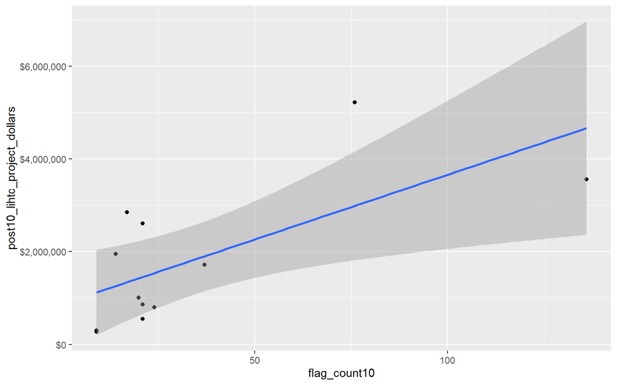

```r
# Cluster 2 Scatterplot
# y is our independent variable (LIHTC Project Dollars),
# x is our dependent variable (SVI flag count)

svi_divisional_county_lihtc_projects2 %>%
  filter(cluster == 2) %>%
  ggplot2::ggplot(aes(x=flag_count10,
                    y=post10_lihtc_project_dollars)) +
        geom_point() +
        geom_smooth(method="lm") +
        scale_y_continuous(labels = scales::dollar_format())
```

```r
svi_divisional_county_lihtc_projects2 %>%
  filter(cluster == 2) %>%
  select(flag_count10,post10_lihtc_project_dollars) %>%
  cor(method = "pearson")
```

```
##                              flag_count10 post10_lihtc_project_dollars
## flag_count10                    1.0000000                    0.6788349
## post10_lihtc_project_dollars    0.6788349                    1.0000000
```

Cluster 2 contains all but 2 of our data points. With a Pearson’s R of 0.68, there is a strong correlation between LIHTC dollars and SVI need.

Here are the 12 counties in this cluster:

```r
svi_divisional_county_lihtc_projects2 %>%
  filter(cluster == 2) %>%
  select(county_name, flag_count10, post10_lihtc_dollars_formatted) %>%
  arrange(desc(flag_count10)) %>% head(12)
```

```
##             county_name flag_count10 post10_lihtc_dollars_formatted
## 1       Pima County, AZ          136                     $3,557,261
## 2     Denver County, CO           76                     $5,226,128
## 3       Utah County, UT           37                     $1,721,391
## 4   San Juan County, NM           24                       $802,175
## 5       Gila County, AZ           21                       $547,218
## 6       Yuma County, AZ           21                       $864,604
## 7    Larimer County, CO           21                     $2,609,648
## 8    El Paso County, CO           20                     $1,011,891
## 9   Big Horn County, MT           17                     $2,849,000
## 10 Salt Lake County, UT           14                     $1,952,122
## 11    Canyon County, ID            9                       $300,210
## 12   Fremont County, WY            9                       $270,127
```

**Cluster 3**

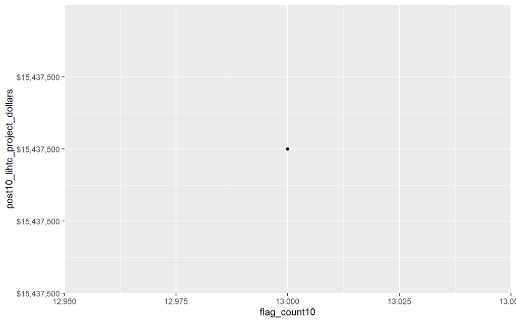

```r
# Cluster 3 Scatterplot
# y is our independent variable (LIHTC Project Dollars),
# x is our dependent variable (SVI flag count)

svi_divisional_county_lihtc_projects2 %>%
  filter(cluster == 3) %>%
  ggplot2::ggplot(aes(x=flag_count10,
                    y=post10_lihtc_project_dollars)) +
        geom_point() +
        geom_smooth(method="lm") +
        scale_y_continuous(labels = scales::dollar_format())
```

Cluster 3 only contains 1 data point so there is no correlation information for this cluster. Here is the county information for this cluster:

```r
svi_divisional_county_lihtc_projects2 %>%
  filter(cluster == 3) %>%
  select(county_name, flag_count10, post10_lihtc_dollars_formatted) %>%
  arrange(desc(flag_count10)) %>% head(10)
```

```
##       county_name flag_count10 post10_lihtc_dollars_formatted
## 1 Mesa County, CO           13                    $15,437,500
```

**In summary, after clustering, we pulled out 1 county outlier with a high flag count (Maricopa County, AZ) and 1 county outlier with a high dollar amount (Mesa County, CO), and our correlation between LIHTC funding received in 2011-2020 is strongly correlated with the SVI vulnerability flag count in 2010.

### Bivariate Mapping

```r
# Join our LIHTC projects data with our shapefile geocoordinates
svi_divisional_county_lihtc_sf <- left_join(svi_divisional_county_lihtc_projects, divisional_county_sf, join_by("FIPS_st" == "STATEFP", "FIPS_county" == "COUNTYFP"))

svi_divisional_county_lihtc_sf %>% head(5)
```

```
##   State          County          Division post10_lihtc_project_cnt tract_cnt
## 1    AZ     Gila County Mountain Division                        1         2
## 2    AZ Maricopa County Mountain Division                       14        48
## 3    AZ     Pima County Mountain Division                        4        17
## 4    AZ     Yuma County Mountain Division                        1         2
## 5    CO   Denver County Mountain Division                        6         8
##   post10_lihtc_project_dollars post10_lihtc_dollars_formatted fips_county_st
## 1                       547218                       $547,218          04007
## 2                     13115292                    $13,115,292          04013
## 3                      3557261                     $3,557,261          04019
## 4                       864604                       $864,604          04027
## 5                      5226128                     $5,226,128          08031
##   FIPS_st FIPS_county state_name region_number      region division_number
## 1      04         007    Arizona             4 West Region               8
## 2      04         013    Arizona             4 West Region               8
```

[output cut: 21 more lines]

```r
# Create classes for bivariate mapping
svi_divisional_county_lihtc_sf <- bi_class(svi_divisional_county_lihtc_sf, x = flag_count10, y = post10_lihtc_project_dollars, style = "quantile", dim = 3)

# View data
svi_divisional_county_lihtc_sf %>% head(5)
```

```
##   State          County          Division post10_lihtc_project_cnt tract_cnt
## 1    AZ     Gila County Mountain Division                        1         2
## 2    AZ Maricopa County Mountain Division                       14        48
## 3    AZ     Pima County Mountain Division                        4        17
## 4    AZ     Yuma County Mountain Division                        1         2
## 5    CO   Denver County Mountain Division                        6         8
##   post10_lihtc_project_dollars post10_lihtc_dollars_formatted fips_county_st
## 1                       547218                       $547,218          04007
## 2                     13115292                    $13,115,292          04013
## 3                      3557261                     $3,557,261          04019
## 4                       864604                       $864,604          04027
## 5                      5226128                     $5,226,128          08031
##   FIPS_st FIPS_county state_name region_number      region division_number
## 1      04         007    Arizona             4 West Region               8
## 2      04         013    Arizona             4 West Region               8
```

[output cut: 21 more lines]

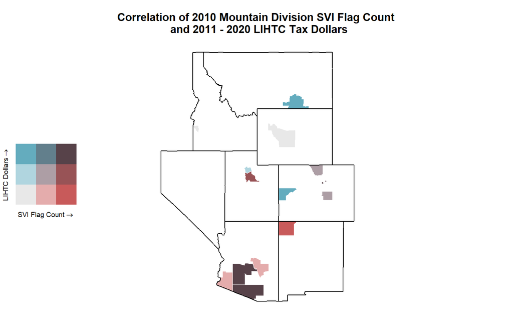

```r
# Create map with ggplot
svi_divisional_county_lihtc_map <- ggplot() +
  # Map county shapefile, fill with bi_class categories
  geom_sf(data = svi_divisional_county_lihtc_sf, mapping = aes(geometry=geometry, fill = bi_class), color = "white", size = 0.1, show.legend = FALSE) +
  # Set to biscale palette
  bi_scale_fill(pal = "GrPink", dim = 3) +
  # Add state shapefiles for outline
  geom_sf(data=divisional_st_sf, color="black", fill=NA, linewidth=.5, aes(geometry=geometry)) +
  labs(
    title = paste0("Correlation of 2010 ", census_division, " SVI Flag Count \n and 2011 - 2020 LIHTC Tax Dollars")
  ) +
  # Set them to biscale
  bi_theme(base_size = 10)

# Create biscale legend
svi_divisional_county_lihtc_legend <- bi_legend(pal = "GrPink",
                    dim = 3,
                    xlab = "SVI Flag Count",
                    ylab = "LIHTC Dollars",
                    size = 8)

# Combine map with legend using cowplot
svi_divisional_county_lihtc_bivarmap <- ggdraw() +
  draw_plot(svi_divisional_county_lihtc_map) +
  # Set legend location
  draw_plot(svi_divisional_county_lihtc_legend, x= -.02,  y = -.05,
 width=.20)


# View map
svi_divisional_county_lihtc_bivarmap
```

```r
svi_divisional_county_lihtc_sf %>% filter(State == "AZ") %>% select(State, County, flag_count10, post10_lihtc_dollars_formatted) %>% arrange(desc(flag_count10)) %>% head()
```

```
##   State          County flag_count10 post10_lihtc_dollars_formatted
## 1    AZ Maricopa County          487                    $13,115,292
## 2    AZ     Pima County          136                     $3,557,261
## 3    AZ     Gila County           21                       $547,218
## 4    AZ     Yuma County           21                       $864,604
```

Again, Montana and Colorado received high funding dollars for a low amount of need:

```r
svi_divisional_county_lihtc_sf %>% filter(State %in% c("MT", "CO")) %>%
  arrange(desc(post10_lihtc_project_dollars), flag_count10) %>% select(State, County, flag_count10, post10_lihtc_dollars_formatted) %>% head(10)
```

```
##   State          County flag_count10 post10_lihtc_dollars_formatted
## 1    CO     Mesa County           13                    $15,437,500
## 2    CO   Denver County           76                     $5,226,128
## 3    MT Big Horn County           17                     $2,849,000
## 4    CO  Larimer County           21                     $2,609,648
## 5    CO  El Paso County           20                     $1,011,891
```

```r
#Save Data Sets

saveRDS(svi_divisional_lihtc, file = here::here(paste0("data/wrangling/", str_replace_all(census_division, " ", "_"), "_svi_divisional_lihtc.rds")))

saveRDS(svi_national_lihtc, file = here::here(paste0("data/wrangling/", str_replace_all(census_division, " ", "_"), "_svi_national_lihtc.rds")))

saveRDS(svi_divisional_nmtc, file = here::here(paste0("data/wrangling/", str_replace_all(census_division, " ", "_"), "_svi_divisional_nmtc.rds")))

saveRDS(svi_national_nmtc, file = here::here(paste0("data/wrangling/", str_replace_all(census_division, " ", "_"), "_svi_national_nmtc.rds")))
```